# Исследование тарифных планов оператора мобильной связи

Оператор мобильной связи планирует рекламную кампанию с целью привлечения новых клиентов, удержания существующих, а также с целью повышения узнаваемости своего бренда на рынке. Это помогает обеспечивать рост и прибыльность компании.

Конкурентная борьба и постоянное изменение рыночных условий приводит к необходимости корректировать рекламный бюджет компании мобильного оператора. В каком направлении следует перенаправить вложения и в каком объёме — зависит от стратегии компании и её целей. Одним из таких направлений может являться продвижение на рынке более прибыльного для компании тарифного плана с целью увеличения выручки.

Прибыльным компания может считать такой тарифный план, для которого средняя выручка от одного абонента больше, чем для других тарифных планов. В таком случае, косвенно (при прочих равных условиях) компания может считать прибыльным такой тарифный план, количество абонентов которого больше. Но если тарифные планы существенно отличаются друг от друга, то прибыльным будет тот тарифный план, суммарная выручка от всех абонентов которого, превышает такую от абонентов любого другого тарифного плана (в условиях текущего распределения абонентов между тарифными планами).

Чтобы определить, какой тарифный план приносит больше выручки, необходимо проанализировать, сколько каждый абонент тратит в месяц на услуги мобильной связи: какую платит абонентскую плату за пользование тарифным планом и какой у него ежемесячный расход на дополнительные услуги связи (дополнительные минуты звонков, гигабайты интернета и смс-сообщения). Анализ использования абонентом услуг связи позволяет определить, какие услуги наиболее востребованы среди пользователей и какие тарифные планы наиболее выгодны для оператора. А анализ выручки с каждого клиента позволяет определить, какой тарифный план приносит большую выручку.

Исследование всей клиентской базы может быть ресурсоёмким и времязатратным процессом. Поэтому сначала проводят предварительный анализ использования тарифных планов на небольшой выборке клиентов. Если выборка является статистически репрезентативной и представляет широкий спектр клиентов, предварительный анализ на ней может дать достаточно точное представление о поведении и предпочтениях клиентов в целом.

В нашем распоряжении находятся данные о поведении пользователей тарифных планов оператора мобильной связи. Для каждого абонента доступна информация о совершённых им звонках, отправленных смс-сообщениях и проведённых интернет-сессиях. Также доступна персональная информация абонентов.

**Цель проекта:** определить тарифный план с наибольшей прибыльностью.

**Задачи проекта:**

- выполнить предобработку данных;
- подготовить набор данных для исследовательского анализа;
- изучить сформированный набор данных;
- найти особенности и выявить зависимости между признаками;
- выдвинуть и проверить гипотезы.

# Содержание

## Обзор данных

### Импорт библиотек и предварительные настройки

```python
import pandas as pd
import matplotlib.pyplot as plt
import numpy as np
import seaborn as sns
import sys
import os

from scipy import stats as st

pd.set_option('display.max_columns', None)
np.set_printoptions(threshold=sys.maxsize)
```

### Чтение файлов и загрузка данных

Все данные хранятся в пяти файлах.  
Файлы данных имеют формат `CSV`.

```python
PATHS = [r'C:\Users\Георгий\Documents\DS_projects', '/datasets', '/content']

def read_df(name, paths=PATHS):
    '''
    Функция загрузки данных из CSV-файлов
    с проверкой существования пути к файлу.

    Принимает название файла.
    Возвращает набор данных из файла.
    '''

    for path in paths:
        file_path = os.path.join(path, name)
        if os.path.exists(file_path):
            df = pd.read_csv(file_path)

            return df

    print(f'{name}: Something is wrong')
```

```python
calls = read_df('calls.csv')
sessions = read_df('internet.csv')
messages = read_df('messages.csv')
tariffs = read_df('tariffs.csv')
users = read_df('users.csv')
```

### Общая характеристика наборов данных

Предварительно зададим функции, позволяющие получить основные сведения о наборах данных, отслеживать в наборах данных наличие пропусков и визуализировать их распределение.

```python
def df_info(data):
    '''
    Функция выводит описание набора данных, первые и посление строки,
    а также типы данных набора данных.

    Принимает набор исследуемых данных.
    '''

    display(data.head(2))
    display(data.tail(2))
    print('Размер набора данных:', data.shape)
    print('\nКоличество элементов данных:', data.size)
    print('\nКоличество дубликатов в наименованиях признаков:',
          data.columns.duplicated().sum())
    print('\nУникальные наименования признаков:\n',
          data.columns.sort_values().tolist())
    print('\nКоличество пропущенных значений:',
          data.isna().sum().sum())
    print('\nПроцент пропущенных значений:',
          round(data.isna().sum().sum() / data.size * 100, 1), '%')
    print('\nТипы данных набора данных:')
    display(data.dtypes.value_counts())
```

```python
def show_na(data):
    '''
    Функция выводит количество пропусков в признаках и
    долю пропусков (в процентах) от общего числа записей.

    Принимает набор исследуемых данных.
    Возвращает датафрейм с описанием распределения пропусков.
    '''

    total = data.isna().sum().sort_values(ascending=False)
    percent = (data.isna().sum() /
               data.isna().count() * 100).round(1).sort_values(ascending=False)
    df = pd.concat([total, percent], axis=1, keys=['Всего пропусков', '%'])

    return df
```

```python
def pic_na(data):
    '''
    Функция визуализирует распределение пропусков в наборе данных.

    Принимает набор исследуемых данных.
    '''

    sns.heatmap(data.isna(), cmap=sns.color_palette(['#000000', '#ffffff']))
    plt.title('Тепловая карта\nраспределения пропущенных значений')
    plt.xlabel('Название признака')
    plt.ylabel('Номер записи')
    plt.show()
```

#### Информация о звонках

```python
df_info(calls)
```

|  | id | call_date | duration | user_id |
| --- | --- | --- | --- | --- |
| 0 | 1000_0 | 2018-07-25 | 0.0 | 1000 |
| 1 | 1000_1 | 2018-08-17 | 0.0 | 1000 |

|  | id | call_date | duration | user_id |
| --- | --- | --- | --- | --- |
| 202605 | 1499_218 | 2018-10-06 | 4.27 | 1499 |
| 202606 | 1499_219 | 2018-12-14 | 19.62 | 1499 |

```
Размер набора данных: (202607, 4)

Количество элементов данных: 810428

Количество дубликатов в наименованиях признаков: 0

Уникальные наименования признаков:
 ['call_date', 'duration', 'id', 'user_id']

Количество пропущенных значений: 0

Процент пропущенных значений: 0.0 %

Типы данных набора данных:
```

```
object     2
float64    1
int64      1
Name: count, dtype: int64
```

**Информация о звонках**

- Набор данных содержит 4 уникальных признака и 202 607 записей.
- В наборе данных: 810 428 элементов данных.
- Набор данных содержит данные следующего типа:
  - целочисленный — 1 признак,
  - вещественный — 1 признак,
  - смешанного типа — 2 признака.
- Все признаки содержат значения (не являются пустыми).
- Все признаки не содержат пропущенные значения.

#### Информация об интернет-сессиях

```python
df_info(sessions)
```

|  | Unnamed: 0 | id | mb_used | session_date | user_id |
| --- | --- | --- | --- | --- | --- |
| 0 | 0 | 1000_0 | 112.95 | 2018-11-25 | 1000 |
| 1 | 1 | 1000_1 | 1052.81 | 2018-09-07 | 1000 |

|  | Unnamed: 0 | id | mb_used | session_date | user_id |
| --- | --- | --- | --- | --- | --- |
| 149394 | 149394 | 1499_155 | 1246.32 | 2018-11-26 | 1499 |
| 149395 | 149395 | 1499_156 | 544.37 | 2018-10-26 | 1499 |

```
Размер набора данных: (149396, 5)

Количество элементов данных: 746980

Количество дубликатов в наименованиях признаков: 0

Уникальные наименования признаков:
 ['Unnamed: 0', 'id', 'mb_used', 'session_date', 'user_id']

Количество пропущенных значений: 0

Процент пропущенных значений: 0.0 %

Типы данных набора данных:
```

```
int64      2
object     2
float64    1
Name: count, dtype: int64
```

#### Информация о сообщениях

```python
df_info(messages)
```

|  | id | message_date | user_id |
| --- | --- | --- | --- |
| 0 | 1000_0 | 2018-06-27 | 1000 |
| 1 | 1000_1 | 2018-10-08 | 1000 |

|  | id | message_date | user_id |
| --- | --- | --- | --- |
| 123034 | 1499_182 | 2018-11-15 | 1499 |
| 123035 | 1499_183 | 2018-11-16 | 1499 |

```
Размер набора данных: (123036, 3)

Количество элементов данных: 369108

Количество дубликатов в наименованиях признаков: 0

Уникальные наименования признаков:
 ['id', 'message_date', 'user_id']

Количество пропущенных значений: 0

Процент пропущенных значений: 0.0 %

Типы данных набора данных:
```

```
object    2
int64     1
Name: count, dtype: int64
```

**Информация о сообщениях**

- Набор данных содержит 3 уникальных признака и 123 036 записей.
- В наборе данных: 369 108 элементов данных.
- Набор данных содержит данные следующего типа:
  - целочисленный — 1 признак,
  - смешанного типа — 2 признака.
- Все признаки содержат значения (не являются пустыми).
- Все признаки не содержат пропущенные значения.

#### Информация о тарифах

```python
df_info(tariffs)
```

|  | messages_included | mb_per_month_included | minutes_included | rub_monthly_fee | rub_per_gb | rub_per_message | rub_per_minute | tariff_name |
| --- | --- | --- | --- | --- | --- | --- | --- | --- |
| 0 | 50 | 15360 | 500 | 550 | 200 | 3 | 3 | smart |
| 1 | 1000 | 30720 | 3000 | 1950 | 150 | 1 | 1 | ultra |

|  | messages_included | mb_per_month_included | minutes_included | rub_monthly_fee | rub_per_gb | rub_per_message | rub_per_minute | tariff_name |
| --- | --- | --- | --- | --- | --- | --- | --- | --- |
| 0 | 50 | 15360 | 500 | 550 | 200 | 3 | 3 | smart |
| 1 | 1000 | 30720 | 3000 | 1950 | 150 | 1 | 1 | ultra |

```
Размер набора данных: (2, 8)

Количество элементов данных: 16

Количество дубликатов в наименованиях признаков: 0

Уникальные наименования признаков:
 ['mb_per_month_included', 'messages_included', 'minutes_included', 'rub_monthly_fee', 'rub_per_gb', 'rub_per_message', 'rub_per_minute', 'tariff_name']

Количество пропущенных значений: 0

Процент пропущенных значений: 0.0 %

Типы данных набора данных:
```

```
int64     7
object    1
Name: count, dtype: int64
```

**Информация о тарифах**

- Набор данных содержит 8 уникальных признаков и 2 записи.
- В наборе данных: 16 элементов данных.
- Набор данных содержит данные следующего типа:
  - целочисленный — 7 признаков,
  - смешанного типа — 1 признак.
- Все признаки содержат значения (не являются пустыми).
- Все признаки не содержат пропущенные значения.

#### Информация о пользователях

```python
df_info(users)
```

|  | user_id | age | churn_date | city | first_name | last_name | reg_date | tariff |
| --- | --- | --- | --- | --- | --- | --- | --- | --- |
| 0 | 1000 | 52 | NaN | Краснодар | Рафаил | Верещагин | 2018-05-25 | ultra |
| 1 | 1001 | 41 | NaN | Москва | Иван | Ежов | 2018-11-01 | smart |

|  | user_id | age | churn_date | city | first_name | last_name | reg_date | tariff |
| --- | --- | --- | --- | --- | --- | --- | --- | --- |
| 498 | 1498 | 68 | 2018-10-25 | Владикавказ | Всеволод | Акимчин | 2018-07-19 | smart |
| 499 | 1499 | 35 | NaN | Пермь | Гектор | Корнилов | 2018-09-27 | smart |

```
Размер набора данных: (500, 8)

Количество элементов данных: 4000

Количество дубликатов в наименованиях признаков: 0

Уникальные наименования признаков:
 ['age', 'churn_date', 'city', 'first_name', 'last_name', 'reg_date', 'tariff', 'user_id']

Количество пропущенных значений: 462

Процент пропущенных значений: 11.6 %

Типы данных набора данных:
```

```
object    6
int64     2
Name: count, dtype: int64
```

```python
show_na(users)
```

|  | Всего пропусков | % |
| --- | --- | --- |
| churn_date | 462 | 92.4 |
| user_id | 0 | 0.0 |
| age | 0 | 0.0 |
| city | 0 | 0.0 |
| first_name | 0 | 0.0 |
| last_name | 0 | 0.0 |
| reg_date | 0 | 0.0 |
| tariff | 0 | 0.0 |

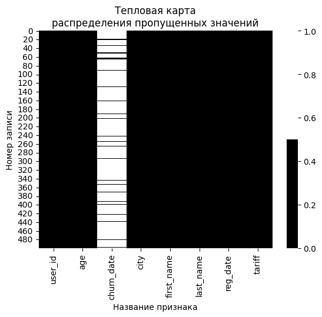

```python
pic_na(users)
```

**Информация о пользователях**

- Набор данных содержит 8 уникальных признаков и 500 записей.
- В наборе данных: 4000 элементов данных.
- Набор данных содержит данные следующего типа:
  - целочисленный — 2 признака,
  - смешанного типа — 6 признаков.
- Все признаки содержат значения (не являются пустыми).
- 7 признаков не содержат пропущенные значения.
- 1 признак содержит пропущенные значения:
  - распределение пропусков в данных не носит регулярный характер,
  - всего в данных 462 пропущенных значений — около 11,6 % от всех элементов данных и 92,4 % от всех значений признака `churn_date`.

## Понимание данных

***Информация о пользователях***

> **Уникальный идентификатор пользователя** — это уникальный код или номер, который присваивается каждому клиенту компании мобильного оператора для идентификации его в системе компании.

Идентификатор может использоваться для доступа к информации о клиенте, его счетах, используемых услугах и расходах. Как правило, уникальный идентификатор представлен в виде цифр или буквенно-цифровой комбинации.

`user_id` — уникальный идентификатор пользователя  
Признак является категориальным, ординальным.  
Шкала измерения признака: порядковая шкала.

> **Персональные данные клиента** — это любая информация, которая относится к конкретному человеку и позволяет однозначно его идентифицировать.

К персональным данным относятся сведения о фамилии, имени, поле клиента, его местонахождении.

`last_name` — фамилия пользователя  
Признак является категориальным, номинальным.  
Шкала измерения признака: номинальная шкала.

`first_name` — имя пользователя  
Признак является категориальным, номинальным.  
Шкала измерения признака: номинальная шкала.

`age` — возраст пользователя (лет)  
Признак является количественным, непрерывным.  
Шкала измерения признака: интервальная шкала.

`city` — город проживания пользователя  
Признак является категориальным, номинальным.  
Шкала измерения признака: номинальная шкала.

> **Дата подключения** пользователем тарифного плана — это дата, когда абонент подписывает договор и начинает использовать выбранный тарифный план.

> **Дата прекращения пользования** тарифным планом — это дата, когда абонент расторгает договор или переходит на другой тарифный план.

`reg_date` — дата подключения тарифного плана  
Признак является количественным, дискретным.  
Шкала измерения признака: интервальная шкала.

`churn_date`* — дата прекращения пользования тарифным планом  
Признак является количественным, дискретным.  
Шкала измерения признака: интервальная шкала.  
* Если значение пропущено, значит, тариф ещё действовал на момент выгрузки данных.

***Информация о звонках***

> **Уникальный идентификатор совершённого звонка** — это уникальный номер или код, который идентифицирует каждый отдельный звонок.

Этот идентификатор используется для отслеживания и классификации звонков в системе управления клиентской базой.

`id`(таблица calls) — уникальный идентификатор совершённого звонка  
Признак является категориальным, номинальным.  
Шкала измерения признака: номинальная шкала.

> **Длительность звонка** — это период времени, в течение которого была установлена голосовая связь.

`duration` — длительность звонка (мин)  
Признак является количественным, непрерывным.  
Шкала измерения признака: шкала отношений.

> **Дата совершения звонка** — это дата, когда была установлена голосовая связь (или выполнена попытка её установить).

`call_date` — дата совершения звонка  
Признак является количественным, дискретным.  
Шкала измерения признака: интервальная шкала.

***Информация об интернет-сессиях***

> **Уникальный идентификатор проведённой интернет-сессии** — это уникальный код или номер, который идентифицирует конкретную сессию пользователя в сети Интернет.

Каждый раз, когда пользователь выходит в интернет, ему присваивается новый уникальный идентификатор, который помогает системе управления клиентской базой отличать его сессию от других.

`id`(таблица sessions) — уникальный идентификатор проведённой интернет-сессии  
Признак является категориальным, номинальным.  
Шкала измерения признака: номинальная шкала.

> **Объём израсходованного за сессию интернет-трафика** — это количество данных, которое было передано или получено во время выполнения интернет-сессии.

`mb_used` — объём израсходованного за сессию интернет-трафика (Мбайт)  
Признак является количественным, непрерывным.  
Шкала измерения признака: абсолютная шкала.

> **Дата проведения интернет-сессии** — это дата, когда было выполнено подключение к сети Интернет (или совершена попытка выполнить такое подключение).

`session_date` — дата проведения интернет-сессии  
Признак является количественным, дискретным.  
Шкала измерения признака: интервальная шкала.

***Информация о смс-сообщениях***

> **Уникальный идентификатор отправленного смс-сообщения** — это уникальный номер или код, присвоенный каждому отправленному сообщению.

Этот идентификатор используется для отслеживания и классификации смс-сообщений в системе управления клиентской базой.

`id`(таблица messages) — уникальный идентификатор отправленного смс-сообщения  
Признак является категориальным, номинальным.  
Шкала измерения признака: номинальная шкала.

> **Дата отправки смс-сообщения** — это дата, когда сообщение было передано в сеть оператора для его доставки получателю.

`message_date` — дата отправки смс-сообщения  
Признак является количественным, дискретным.  
Шкала измерения признака: интервальная шкала.

***Информация о тарифах***

`tariff`(таблица users), `tariff_name`(таблица tariffs) — название тарифного плана

`rub_monthly_fee` — ежемесячная абонентская плата (руб.)

`minutes_included` — количество минут разговора в месяц, включённых в абонентскую плату

`messages_included` — количество сообщений в месяц, включённых в абонентскую плату

`mb_per_month_included` — объём интернет-трафика, включённого в абонентскую плату (Мбайт)

`rub_per_minute` — стоимость минуты разговора сверх тарифного пакета

`rub_per_message` — стоимость отправки сообщения сверх тарифного пакета

`rub_per_gb` — стоимость дополнительного гигабайта интернет-трафика сверх тарифного пакета

*Описание тарифов*

| Тарифный план | Смарт | Ультра |
| --- | --- | --- |
| Ежемесячная плата, руб. | 550 | 1950 |
| **Основные услуги:** |  |  |
| – минуты разговора | 500 | 3000 |
| – смс-сообщения | 50 | 1000 |
| – интернет-трафик, Гбайт | 15 | 30 |
| **Дополнительные услуги:** |  |  |
| – 1 минута разговора, руб. | 3 | 1 |
| – 1 сообщение, руб. | 3 | 1 |
| – 1 Гбайт интернет-трафика, руб. | 200 | 150 |

## Описание данных

```python
def descriptive_statistics(values, label):
    '''
    Описательная статистика переменной, измеряемой в количественной шкале.

    Принимает значения признака и название признака.
    Возвращает DataFrame с набором статистик.

    '''

    df = pd.DataFrame([
        values.count(),
        len(values.unique()),
        values.min(),
        values.median() - 1.5 * (values.quantile(q=.75) -
                                 values.quantile(q=.25)),
        values.quantile(q=.25).round(2),
        (values.mode()).to_list(),
        values.median().round(2),
        values.mean().round(2),
        values.quantile(q=.75).round(2),
        values.median() + 1.5 * (values.quantile(q=.75) -
                                 values.quantile(q=.25)),
        values.max(),
        values.max() - values.min(),
        values.quantile(q=.75) - values.quantile(q=.25)
    ],
        index=['кол-во значений', 'кол-во уникальных', 'мин.',
               '-1.5IQR', '25 %', 'мода', 'медиана',
               'среднее ариф.', '75 %', '+1.5IQR', 'макс.',
               'размах', 'межквартильный размах'],
        columns=[label])

    return df
```

```python
def graph(data, title, xlabel, bins=100):
    '''
    Функция строит диаграмму распределения значений и диаграмму размаха
    исследуемых данных.

    Принимает набор исследуемых данных,
    название признака для заголовка графика,
    подпись оси Ox.
    '''

    fig, (ax1, ax2) = plt.subplots(2, 1, figsize=(15, 6))
    ax1.set_title('Диаграмма распределения и диаграмма размаха' +
                  f'\nзначений {title}')
    ax1.hist(data, bins=bins)
    ax1.tick_params(labelbottom=False)
    ax1.set_ylabel('Частота')
    ax2.boxplot(data, vert=False)
    ax2.tick_params(left=False, labelleft=False)
    ax2.set_xlabel(f'{xlabel}')
    plt.show()
```

```python
def day(data, label):
    '''
    Функция описывает временной признак (дни).

    Принимает набор исследуемых данных и название признака.
    Возвращает датафрейм с характеристиками распределения временных значений.
    '''

    data = pd.to_datetime(data)
    stat = pd.DataFrame(pd.to_datetime(data).dt.date.describe()).rename(
        columns={pd.DataFrame(data).columns[0]: label},
        index={'count': 'кол-во значений',
               'unique': 'кол-во уникальных',
               'top': 'мода',
               'freq': 'частота моды'}).T
    stat.loc[label, 'мода'] = stat.loc[label, 'мода'].strftime('%d.%m.%Y')
    stat['мин'] = data.min().strftime('%d.%m.%Y')
    stat['медиана'] = data.quantile(q=.5).strftime('%d.%m.%Y')
    stat['макс'] = data.max().strftime('%d.%m.%Y')
    stat['размах'] = (data.max() - data.min()).days + 1
    stat['межквартильный размах'] = (data.quantile(q=.75) -
                                     data.quantile(q=.25)).days

    return stat.T
```

### Информация о пользователях

***Уникальный идентификатор пользователя***

```python
print('Количество клиентов:', len(users['user_id'].unique()))
```

```
Количество клиентов: 500
```

***Фамилия пользователя***

```python
print('Количество разных фамилий клиентов:', len(users['last_name'].unique()))
```

```
Количество разных фамилий клиентов: 419
```

```python
print('Таблица частот топ-5 фамилий')
pd.DataFrame(users['last_name'].value_counts()).head().reset_index().rename(
    columns={'last_name': 'Фамилия', 'count': 'Количество клиентов'})
```

```
Таблица частот топ-5 фамилий
```

|  | Фамилия | Количество клиентов |
| --- | --- | --- |
| 0 | Андреенко | 5 |
| 1 | Березина | 3 |
| 2 | Аркадьев | 3 |
| 3 | Булгаков | 3 |
| 4 | Соловьев | 3 |

***Имя пользователя***

```python
print('Количество разных имён клиентов:', len(users['first_name'].unique()))
```

```
Количество разных имён клиентов: 246
```

```python
print('Таблица частот топ-5 имён')
pd.DataFrame(users['first_name'].value_counts()).head().reset_index().rename(
    columns={'first_name': 'Имя', 'count': 'Количество клиентов'})
```

```
Таблица частот топ-5 имён
```

|  | Имя | Количество клиентов |
| --- | --- | --- |
| 0 | Радим | 6 |
| 1 | Леонид | 5 |
| 2 | Пётр | 5 |
| 3 | Андрей | 4 |
| 4 | Адам | 4 |

***Возраст пользователя***

```python
descriptive_statistics(users['age'], 'Возраст, лет')
```

|  | Возраст, лет |
| --- | --- |
| кол-во значений | 500 |
| кол-во уникальных | 58 |
| мин. | 18 |
| -1.5IQR | 1.0 |
| 25 % | 32.0 |
| мода | [42, 53] |
| медиана | 46.0 |
| среднее ариф. | 46.59 |
| 75 % | 62.0 |
| +1.5IQR | 91.0 |
| макс. | 75 |
| размах | 57 |
| межквартильный размах | 30.0 |

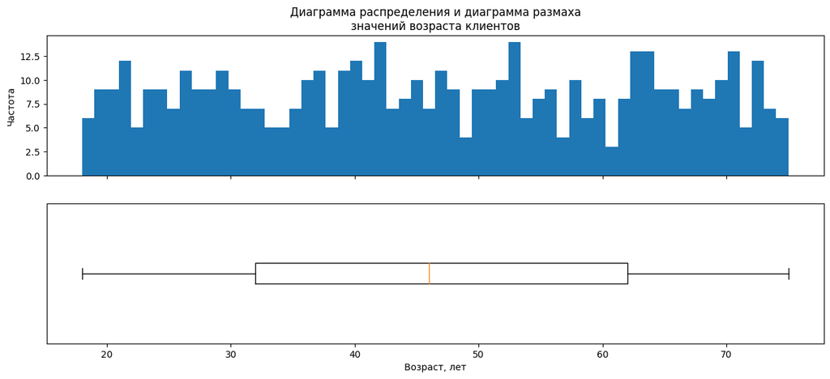

```python
graph(users['age'], 'возраста клиентов', 'Возраст, лет', bins=58)
```

***Город проживания пользователя***

```python
print('Количество разных городов:', len(users['city'].unique()))
```

```
Количество разных городов: 76
```

```python
print('Таблица частот топ-5 городов')
pd.DataFrame(users['city'].value_counts()).head().reset_index().rename(
    columns={'city': 'Город', 'count': 'Количество клиентов'})
```

```
Таблица частот топ-5 городов
```

|  | Город | Количество клиентов |
| --- | --- | --- |
| 0 | Москва | 99 |
| 1 | Санкт-Петербург | 39 |
| 2 | Новосибирск | 16 |
| 3 | Омск | 14 |
| 4 | Казань | 14 |

***Тарифный план пользователя***

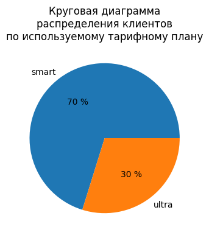

```python
users['tariff'].value_counts().plot(
    kind='pie',
    figsize=(4, 4),
    title='Круговая диаграмма' +
          '\nраспределения клиентов' +
          '\nпо используемому тарифному плану',
    label='',
    autopct='%.0f %%')
plt.show()
```

```python
pd.DataFrame(users['tariff'].value_counts()) \
    .reset_index() \
    .rename(columns={
        'tariff': 'Тарифный план',
        'count': 'Количество пользователей'}
     ).set_index('Тарифный план').T
```

| Тарифный план | smart | ultra |
| --- | --- | --- |
| Количество пользователей | 351 | 149 |

***Даты подключения тарифного плана и прекращения его использования***

```python
day(users['reg_date'], 'Дата подключения').join(
    day(users.loc[users['churn_date'].notna(), 'churn_date'],
        'Дата прекращения пользования')
)
```

|  | Дата подключения | Дата прекращения пользования |
| --- | --- | --- |
| кол-во значений | 500 | 38 |
| кол-во уникальных | 270 | 33 |
| мода | 28.05.2018 | 03.12.2018 |
| частота моды | 8 | 2 |
| мин | 01.01.2018 | 17.08.2018 |
| медиана | 02.07.2018 | 24.11.2018 |
| макс | 31.12.2018 | 30.12.2018 |
| размах | 365 | 136 |
| межквартильный размах | 174 | 62 |

***Доля пользователей, которые отказались от использования тарифного плана***

```python
print('Доля пользователей, расторгших договор:',
      users['churn_date'].notna().mean() * 100, '%')
```

```
Доля пользователей, расторгших договор: 7.6 %
```

- В наборе данных представлены сведения о 500 клиентах.
- Среди них есть клиенты с одинаковой фамилией — однофамильцы или родственники. Наиболее часто встречается фамилия Андреенко — 5 раз. Остальные фамилии встречаются не более 3 раз. Всего в наборе данных встречаются 419 разных фамилий.
- Количество различных имён в наборе данных 246. Чаще всего встречаются имена Радим — 6 раз, Леонид — 5 раз, Пётр — 5 раз. Остальные имена встречаются менее 5 раз.
- Возраст клиентов изменяется от 18 до 75 лет. Чаще всего встречаются клиенты возраста 42 или 53 лет. Средний возраст клиентов составляет 46 лет. Межквартильный размах составляет 30 лет, таким образом, возраст половины клиентов изменяется от 32 до 62 лет. Распределение клиентов по возрасту можно назвать равномерным, с большим количеством шумов на диаграмме распределения.
- Клиенты проживают в 76 различных городах. Наибольшее их число живёт в Москве — 99 человек (около 20 % всех клиентов). Почти в 2,5 раза меньше клиентов из Санкт-Петербурга — 39 человек (почти 8 % всех клиентов). Ещё в 2,5 раза меньше клиентов из Новосибирска — 16 человек (почти 3 % всех клиентов). Из остальных городов количество клиентов не превышает 14 человек.
- Большинство клиентов — 351 человек (70 % всех пользователей) — выбирают тарифный план "Смарт". Остальные 149 человек (30 % всех пользователей) используют тарифный план "Ультра".
- Подключение к тарифному плану происходило в период с 1 января по 31 декабря 2018 года — период наблюдения составил 1 календарный год. Подключения совершались не ежедневно: из 365 дней в году только в 270 из них совершались переходы на указанные тарифные планы. Больше всего подключений было совершено 28 мая — 8 подключений. И хотя распределение количеств подключений в течение года является неравномерным, всё же половина подключений была выполнена в первые 6 месяцев — до 2 июля (медианное значение), а вторая половина — в последние 6 месяцев года.
- Однако не все пользователи продолжают использовать подключенный тарифный план. С 17 августа по 30 декабря было выполнено 38 отключений от рассматриваемых тарифных планов. Максимальное число отключений, совершённых в один день, было 2, и произошло такое событие 3 декабря. Причём половина всех отключений было выполнено за 3 месяца (с 17 августа до 24 ноября (медианное значение)), а вторая половина отключений — за месяц (с 24 ноября по 30 декабря).
- Таким образом, 7,6 % всех пользователей (38 человек из 500) в течение рассматриваемого года после подключения тарифного плана отказались от его использования.

### Информация о звонках

```python
print('Количество пользователей, совершавших звонки:',
      calls['user_id'].nunique())
```

```
Количество пользователей, совершавших звонки: 492
```

***Уникальный идентификатор совершённого звонка***

```python
print('Количество различных совершённых звонков:', len(calls['id'].unique()))
```

```
Количество различных совершённых звонков: 202607
```

***Количество звонков, совершённых одним пользователем***

```python
descriptive_statistics(calls['user_id'].value_counts(), 'Количество звонков')
```

|  | Количество звонков |
| --- | --- |
| кол-во значений | 492 |
| кол-во уникальных | 303 |
| мин. | 14 |
| -1.5IQR | -269.75 |
| 25 % | 180.0 |
| мода | [220, 252] |
| медиана | 344.5 |
| среднее ариф. | 411.8 |
| 75 % | 589.5 |
| +1.5IQR | 958.75 |
| макс. | 1760 |
| размах | 1746 |
| межквартильный размах | 409.5 |

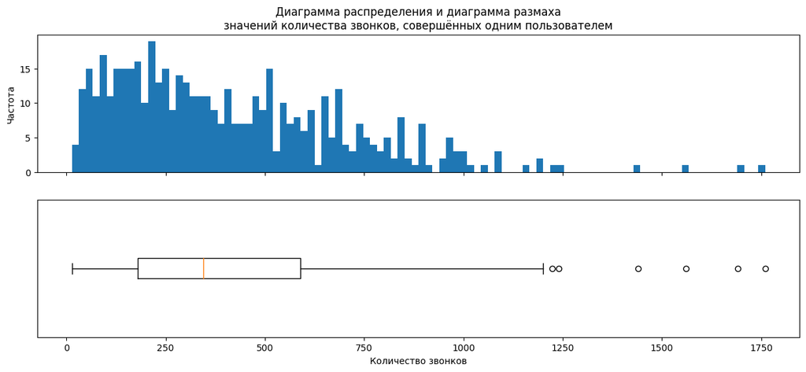

```python
graph(calls['user_id'].value_counts(),
      'количества звонков, совершённых одним пользователем',
      'Количество звонков')
```

***Длительность совершённых звонков***

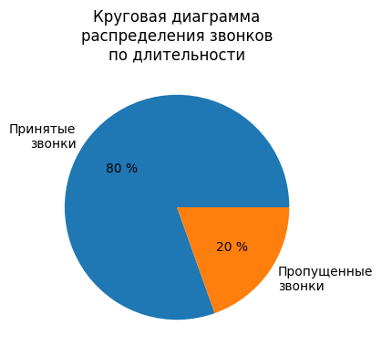

```python
(calls['duration'] > 0).value_counts().rename(
    index={True: 'Принятые\nзвонки',
           False: 'Пропущенные\nзвонки'}
).plot(
    kind='pie',
    figsize=(4, 4),
    title='Круговая диаграмма' +
          '\nраспределения звонков' +
          '\nпо длительности',
    label='',
    autopct='%.0f %%')
plt.show()
```

```python
pd.DataFrame((calls['duration'] > 0).value_counts()).rename(
    index={True: 'Принятые звонки',
           False: 'Пропущенные звонки'}
    ).reset_index().rename(
        columns={'duration': '',
                 'count': 'Количество звонков'}
        ).set_index('').T
```

|  | Принятые звонки | Пропущенные звонки |
| --- | --- | --- |
| Количество звонков | 162994 | 39613 |

```python
descriptive_statistics(calls.loc[calls['duration'] > 0, 'duration'],
                       'Длительность принятого звонка, мин')
```

|  | Длительность принятого звонка, мин |
| --- | --- |
| кол-во значений | 162994 |
| кол-во уникальных | 2870 |
| мин. | 0.01 |
| -1.5IQR | -3.78 |
| 25 % | 4.17 |
| мода | [4.49, 5.5] |
| медиана | 7.74 |
| среднее ариф. | 8.4 |
| 75 % | 11.85 |
| +1.5IQR | 19.26 |
| макс. | 38.0 |
| размах | 37.99 |
| межквартильный размах | 7.68 |

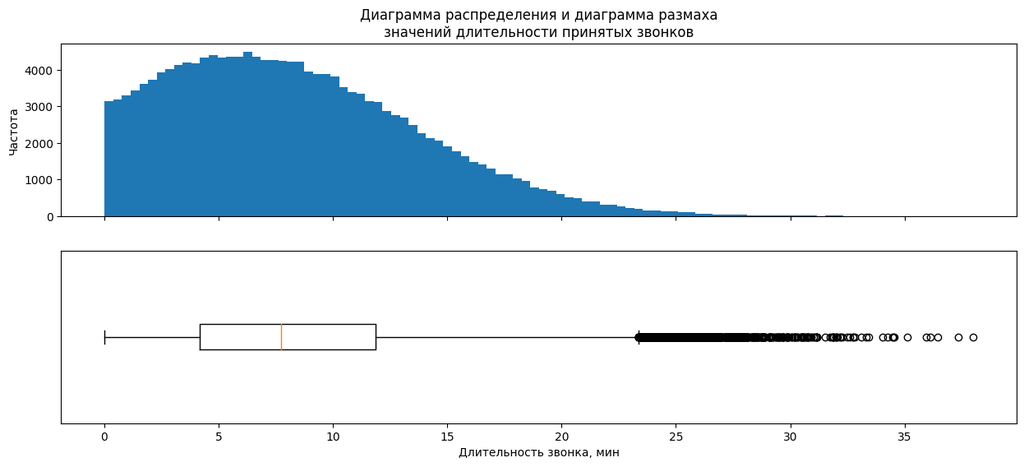

```python
graph(calls.loc[calls['duration'] > 0, 'duration'],
      'длительности принятых звонков', 'Длительность звонка, мин')
```

***Дата совершения звонка***

```python
day(calls['call_date'], 'Дата совершения звонка')
```

|  | Дата совершения звонка |
| --- | --- |
| кол-во значений | 202607 |
| кол-во уникальных | 365 |
| мода | 31.12.2018 |
| частота моды | 1435 |
| мин | 01.01.2018 |
| медиана | 17.09.2018 |
| макс | 31.12.2018 |
| размах | 365 |
| межквартильный размах | 132 |

- Только 492 пользователя из 500 совершали телефонные звонки. 8 человек этой возможностью не воспользовались.
- За рассматриваемый временной период было совершено 202 607 звонков — попыток установления связи, среди которых были как принятые звонки — 162 994 (80 % всех попыток установить связь), так и пропущенные звонки — 39 613 (20 % всех попыток установить связь).
- Количество совершённых одним человеком звонков изменяется от 14 до 1760. Причём чаще всего пользователи совершали 220 или 252 звонка в течение рассматриваемого периода. Распределение значений количества звонков, совершённых одним пользователем, смещено влево, с длинным "хвостом" справа. Медианное значение — 344,5. Межквартильный размах составляет 410 звонков, таким образом, половина пользователей совершала от 180 до 590 звонков за рассматриваемый период. Количество звонков, совершённых одним пользователем, превышающее 960, — явление редкое.
- Среди принятых звонков длительность разговора изменялась от 0,01 до 38 мин. Чаще всего разговор между абонентами продолжался в течение 4,5 или 5,5 мин. Медианная длительность звонка составила 7,7 мин, средняя арифметическая — 8,4 мин. Распределение значений длительности звонков унимодальное, смещено влево, с длинным "хвостом" справа. Межквартильный размах длительности звонков составляет 7,7 мин, таким образом, половина всех звонков длилась от 4,2 до 11,9 мин. Практически все звонки длились не более 19,3 мин. Большая длительность звонков — явление редкое.
- Звонки совершались в течение всего наблюдаемого периода — с 1 января по 31 декабря 2018 года. Половина всех звонков совершена до 17 сентября, вторая половина — после. Больше всего звонков — 1435 — было выполнено 31 декабря.

### Информация об интернет-сессиях

```python
print('Количество пользователей, проводивших интернет-сессии:',
      sessions['user_id'].nunique())
```

```
Количество пользователей, проводивших интернет-сессии: 497
```

***Уникальный идентификатор проведённой интернет-сессии***

```python
print('Количество различных проведённых интернет-сессий:',
      len(sessions['id'].unique()))
```

```
Количество различных проведённых интернет-сессий: 149396
```

***Количество интернет-сессий, проведённых одним пользователем***

```python
descriptive_statistics(sessions['user_id'].value_counts(),
                       'Количество интернет-сессий')
```

|  | Количество интернет-сессий |
| --- | --- |
| кол-во значений | 497 |
| кол-во уникальных | 346 |
| мин. | 8 |
| -1.5IQR | -119.5 |
| 25 % | 155.0 |
| мода | [108] |
| медиана | 284.0 |
| среднее ариф. | 300.6 |
| 75 % | 424.0 |
| +1.5IQR | 687.5 |
| макс. | 834 |
| размах | 826 |
| межквартильный размах | 269.0 |

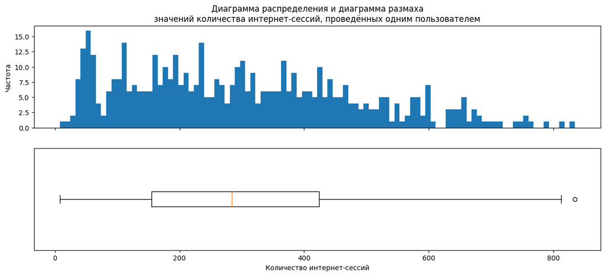

```python
graph(sessions['user_id'].value_counts(),
      'количества интернет-сессий, проведённых одним пользователем',
      'Количество интернет-сессий')
```

***Объём израсходованного за сессию интернет-трафика***

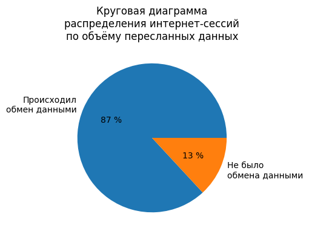

```python
(sessions['mb_used'] > 0).value_counts().rename(
    index={True: 'Происходил\nобмен данными',
           False: 'Не было\nобмена данными'}
).plot(
    kind='pie',
    figsize=(4, 4),
    title='Круговая диаграмма' +
          '\nраспределения интернет-сессий' +
          '\nпо объёму пересланных данных',
    label='',
    autopct='%.0f %%')
plt.show()
```

```python
pd.DataFrame((sessions['mb_used'] > 0).value_counts()).rename(
    index={True: 'Происходил обмен данными',
           False: 'Не было обмена данными'}
    ).reset_index().rename(
        columns={'mb_used': '',
                 'count': 'Количество интернет-сессий'}
        ).set_index('').T
```

|  | Происходил обмен данными | Не было обмена данными |
| --- | --- | --- |
| Количество интернет-сессий | 129798 | 19598 |

```python
descriptive_statistics(sessions.loc[sessions['mb_used'] > 0, 'mb_used'],
                       'Объём израсходованного интернет-трафика, Мбайт')
```

|  | Объём израсходованного интернет-трафика, Мбайт |
| --- | --- |
| кол-во значений | 129798 |
| кол-во уникальных | 70002 |
| мин. | 0.03 |
| -1.5IQR | -147.69125 |
| 25 % | 227.46 |
| мода | [197.56, 335.91, 447.3] |
| медиана | 400.54 |
| среднее ариф. | 426.09 |
| 75 % | 592.95 |
| +1.5IQR | 948.77125 |
| макс. | 1724.83 |
| размах | 1724.8 |
| межквартильный размах | 365.4875 |

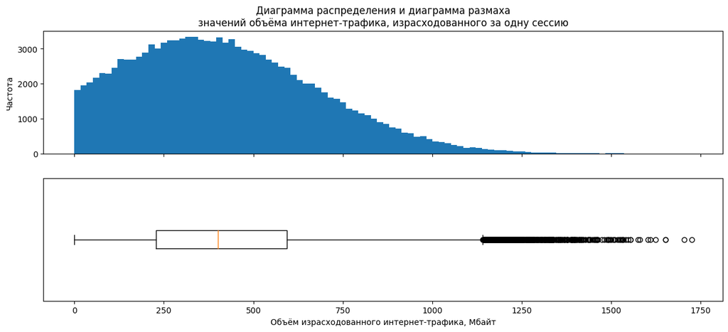

```python
graph(sessions.loc[sessions['mb_used'] > 0, 'mb_used'],
      'объёма интернет-трафика, израсходованного за одну сессию',
      'Объём израсходованного интернет-трафика, Мбайт')
```

***Дата проведения интернет-сессии***

```python
day(sessions['session_date'], 'Дата проведения интернет-сессии')
```

|  | Дата проведения интернет-сессии |
| --- | --- |
| кол-во значений | 149396 |
| кол-во уникальных | 365 |
| мода | 31.12.2018 |
| частота моды | 1057 |
| мин | 01.01.2018 |
| медиана | 17.09.2018 |
| макс | 31.12.2018 |
| размах | 365 |
| межквартильный размах | 132 |

- Только 497 пользователей из 500 проводили интернет-сессии. 3 человека этой возможностью не воспользовались.
- За рассматриваемый временной период было проведено 149 396 интернет-сессий, причём в 19 598 случаях не происходил обмен данными (13 % всех интернет-сессий), а в 129 798 случаях обмен данными происходил (87 % всех интернет-сессий).
- Количество проведённых одним человеком интернет-сессий изменяется от 8 до 834. Причём чаще всего пользователи проводили 108 интернет-сессий в течение рассматриваемого периода. Распределение значений количества интернет-сессий, проведённых одним пользователем, смещено влево. Медианное значение — 284. Межквартильный размах составляет 269 интернет-сессий, таким образом, половина пользователей проводила от 155 до 424 интернет-сессий за рассматриваемый период. Количество интернет-сессий, проведённых одним пользователем, превышающее 687, — явление редкое.
- В тех интернет-сессиях, в которых происходил обмен данными, объём израсходованного трафика изменялся от 0,03 до 1725 Мбайт. Чаще всего объём трафика достигал значений 198, 336 или 447 Мбайт за сессию. Медианный объём трафика — 401 Мбайт, средний арифметический — 426 Мбайт. Распределение значений длительности звонков унимодальное, смещено влево, с длинным "хвостом" справа. Межквартильный размах объёма израсходованного трафика составляет 366 Мбайт, таким образом, в течение половины всех сессий расходовалось от 227 до 593 Мбайт. Практически всегда за сессию расходовалось не более 949 Мбайт интернет-трафика. Больший объём израсходованного трафика — явление редкое.
- Интернет-сессии проводились в течение всего наблюдаемого периода — с 1 января по 31 декабря 2018 года. Половина всех интернет-сессий проведена до 17 сентября, вторая половина — после. Больше всего интернет-сессий — 1057 — было проведено 31 декабря.

### Информация о смс-сообщениях

```python
print('Количество пользователей, отправлявших смс-сообщения:',
      messages['user_id'].nunique())
```

```
Количество пользователей, отправлявших смс-сообщения: 426
```

***Уникальный идентификатор отправленного смс-сообщения***

```python
print('Количество отправленных смс-сообщений:', len(messages['id'].unique()))
```

```
Количество отправленных смс-сообщений: 123036
```

***Количество смс-сообщений, отправленных одним пользователем***

```python
descriptive_statistics(messages['user_id'].value_counts(),
                       'Количество отправленных смс-сообщений')
```

|  | Количество отправленных смс-сообщений |
| --- | --- |
| кол-во значений | 426 |
| кол-во уникальных | 275 |
| мин. | 1 |
| -1.5IQR | -276.875 |
| 25 % | 85.75 |
| мода | [168] |
| медиана | 215.5 |
| среднее ариф. | 288.82 |
| 75 % | 414.0 |
| +1.5IQR | 707.875 |
| макс. | 1463 |
| размах | 1462 |
| межквартильный размах | 328.25 |

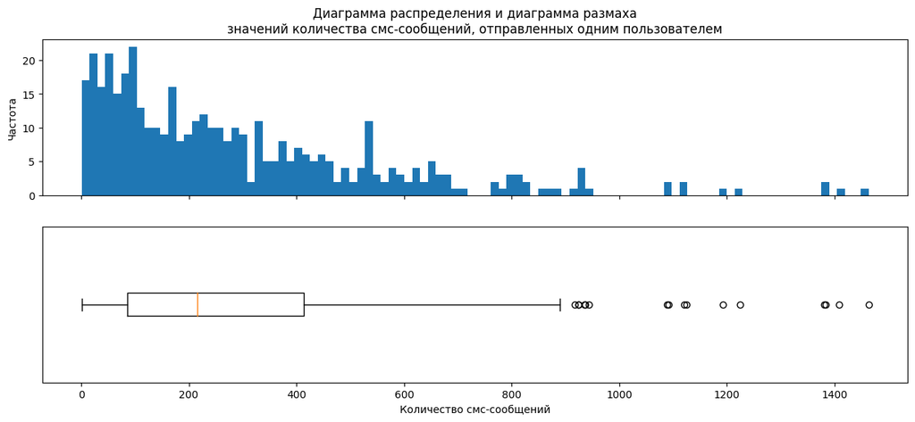

```python
graph(messages['user_id'].value_counts(),
      'количества смс-сообщений, отправленных одним пользователем',
      'Количество смс-сообщений')
```

***Дата отправки смс-сообщений***

```python
day(messages['message_date'], 'Дата отправки смс-сообщения')
```

|  | Дата отправки смс-сообщения |
| --- | --- |
| кол-во значений | 123036 |
| кол-во уникальных | 364 |
| мода | 31.12.2018 |
| частота моды | 859 |
| мин | 02.01.2018 |
| медиана | 20.09.2018 |
| макс | 31.12.2018 |
| размах | 364 |
| межквартильный размах | 128 |

- Только 426 пользователей из 500 отправляли смс-сообщения. 74 человека этой возможностью не воспользовались.
- За рассматриваемый временной период было отправлено 123 036 смс-сообщений.
- Количество отправленных одним человеком смс-сообщений изменяется от 1 до 1463. Причём чаще всего пользователи отправляли 168 смс-сообщений в течение рассматриваемого периода. Распределение значений количества смс-сообщений, отправленных одним пользователем, смещено влево, с длинным "хвостом" справа. Медианное значение — 215,5. Межквартильный размах составляет 328 смс-сообщений, таким образом, половина пользователей отправляла от 86 до 414 смс-сообщений за рассматриваемый период. Количество смс-сообщений, отправленных одним пользователем, превышающее 708, — явление редкое.
- Смс-сообщения отправлялись со 2 января по 31 декабря 2018 года. Половина всех смс-сообщений отправлена до 20 сентября, вторая половина — после. Больше всего смс-сообщений — 859 — было отправлено 31 декабря.

## Предобработка данных

### Изменение типов данных

Преобразуем формат object признаков `reg_date`, `churn_date`, `call_date`, `message_date`, `session_date` к формату даты и времени.

```python
users['reg_date'] = pd.to_datetime(users['reg_date'])
users['churn_date'] = pd.to_datetime(users['churn_date'])
calls['call_date'] = pd.to_datetime(calls['call_date'])
messages['message_date'] = pd.to_datetime(messages['message_date'])
sessions['session_date'] = pd.to_datetime(sessions['session_date'])
```

```python
users[['reg_date', 'churn_date']].dtypes
```

```
reg_date      datetime64[ns]
churn_date    datetime64[ns]
dtype: object
```

```python
calls[['call_date']].dtypes
```

```
call_date    datetime64[ns]
dtype: object
```

```python
messages[['message_date']].dtypes
```

```
message_date    datetime64[ns]
dtype: object
```

```python
sessions[['session_date']].dtypes
```

```
session_date    datetime64[ns]
dtype: object
```

Округлим значения признака `duration` в большую сторону и приведём их к типу integer.

```python
calls['duration'] = np.ceil(calls['duration']).astype('int')
calls['duration'].sort_values().unique()
```

```
array([ 0,  1,  2,  3,  4,  5,  6,  7,  8,  9, 10, 11, 12, 13, 14, 15, 16,
       17, 18, 19, 20, 21, 22, 23, 24, 25, 26, 27, 28, 29, 30, 31, 32, 33,
       34, 35, 36, 37, 38])
```

### Удаление признаков

Признак `Unnamed: 0` был ошибочно оставлен при сохранении набора данных. Для анализа данных он не представляет ценности. Удалим его.

```python
sessions.drop(columns=['Unnamed: 0'], inplace=True)
sessions.columns
```

```
Index(['id', 'mb_used', 'session_date', 'user_id'], dtype='object')
```

### Обработка хронометрических данных

Создание признака "Месяц" совершения звонка.

```python
calls['month'] = pd.DatetimeIndex(calls['call_date']).month
calls['month'].sort_values().unique()
```

```
array([ 1,  2,  3,  4,  5,  6,  7,  8,  9, 10, 11, 12])
```

```python
calls[['call_date', 'month']].sample(7)
```

|  | call_date | month |
| --- | --- | --- |
| 176782 | 2018-11-24 | 11 |
| 46046 | 2018-08-27 | 8 |
| 109812 | 2018-02-17 | 2 |
| 153996 | 2018-02-02 | 2 |
| 42452 | 2018-04-24 | 4 |
| 23205 | 2018-05-16 | 5 |
| 75083 | 2018-11-20 | 11 |

Создание признака "Месяц" отправки сообщения.

```python
messages['month'] = pd.DatetimeIndex(messages['message_date']).month
messages['month'].sort_values().unique()
```

```
array([ 1,  2,  3,  4,  5,  6,  7,  8,  9, 10, 11, 12])
```

```python
messages[['message_date', 'month']].sample(7)
```

|  | message_date | month |
| --- | --- | --- |
| 74697 | 2018-09-15 | 9 |
| 78466 | 2018-06-17 | 6 |
| 27538 | 2018-10-06 | 10 |
| 33988 | 2018-10-13 | 10 |
| 20889 | 2018-05-10 | 5 |
| 58341 | 2018-07-07 | 7 |
| 27070 | 2018-01-29 | 1 |

Создание признака "Месяц" проведения интернет-сессии.

```python
sessions['month'] = pd.DatetimeIndex(sessions['session_date']).month
sessions['month'].sort_values().unique()
```

```
array([ 1,  2,  3,  4,  5,  6,  7,  8,  9, 10, 11, 12])
```

```python
sessions[['session_date', 'month']].sample(7)
```

|  | session_date | month |
| --- | --- | --- |
| 64622 | 2018-10-26 | 10 |
| 106870 | 2018-09-04 | 9 |
| 57833 | 2018-07-06 | 7 |
| 7408 | 2018-08-27 | 8 |
| 97563 | 2018-12-21 | 12 |
| 99276 | 2018-08-22 | 8 |
| 85178 | 2018-07-30 | 7 |

### Формирование набора данных

Для проведения исследовательского анализа необходимо сформировать набор данных, в котором для каждого пользователя за каждый месяц использования тарифного плана будет рассчитано общее количество звонков и их суммарная продолжительность, количество интернет-сессий и суммарный объём израсходованного трафика, количество отправленных смс-сообщений.

***Количество звонков, совершённых каждым пользователем в течение каждого месяца***

```python
calls_per_month = calls.groupby(['user_id', 'month']) \
                       .agg(calls=('duration', 'count'))
calls_per_month.head(10)
```

| user_id | month | calls |
| --- | --- | --- |
| 1000 | 5 | 22 |
|  | 6 | 43 |
|  | 7 | 47 |
|  | 8 | 52 |
|  | 9 | 58 |
|  | 10 | 57 |
|  | 11 | 43 |
|  | 12 | 46 |
| 1001 | 11 | 59 |
|  | 12 | 63 |

***Суммарная длительность звонков, совершённых одним пользователем в течение одного месяца***

```python
minutes_per_month = calls.groupby(['user_id', 'month']) \
                         .agg(minutes=('duration', 'sum'))
minutes_per_month.head(10)
```

| user_id | month | minutes |
| --- | --- | --- |
| 1000 | 5 | 159 |
|  | 6 | 172 |
|  | 7 | 340 |
|  | 8 | 408 |
|  | 9 | 466 |
|  | 10 | 350 |
|  | 11 | 338 |
|  | 12 | 333 |
| 1001 | 11 | 430 |
|  | 12 | 414 |

***Количество смс-сообщений, отправленных каждым пользователем в течение каждого месяца***

```python
messages_per_month = messages.groupby(['user_id', 'month']) \
                             .agg(messages=('message_date', 'count'))
messages_per_month.head(10)
```

| user_id | month | messages |
| --- | --- | --- |
| 1000 | 5 | 22 |
|  | 6 | 60 |
|  | 7 | 75 |
|  | 8 | 81 |
|  | 9 | 57 |
|  | 10 | 73 |
|  | 11 | 58 |
|  | 12 | 70 |
| 1002 | 6 | 4 |
|  | 7 | 11 |

***Количество интернет-сессий, проведённых каждым пользователем в течение каждого месяца***

```python
sessions_per_month = sessions.groupby(['user_id', 'month']) \
                             .agg(sessions=('mb_used', 'count'))
sessions_per_month.head(10)
```

| user_id | month | sessions |
| --- | --- | --- |
| 1000 | 5 | 5 |
|  | 6 | 49 |
|  | 7 | 29 |
|  | 8 | 29 |
|  | 9 | 27 |
|  | 10 | 27 |
|  | 11 | 24 |
|  | 12 | 21 |
| 1001 | 11 | 55 |
|  | 12 | 41 |

***Суммарный объём интернет-трафика, израсходованного одним пользователем в течение одного месяца***

```python
mb_used_per_month = sessions.groupby(['user_id', 'month']).agg({'mb_used': 'sum'})
mb_used_per_month.head(10)
```

| user_id | month | mb_used |
| --- | --- | --- |
| 1000 | 5 | 2253.49 |
|  | 6 | 23233.77 |
|  | 7 | 14003.64 |
|  | 8 | 14055.93 |
|  | 9 | 14568.91 |
|  | 10 | 14702.49 |
|  | 11 | 14756.47 |
|  | 12 | 9817.61 |
| 1001 | 11 | 18429.34 |
|  | 12 | 14036.66 |

Объединим рассчитанные значения в один набор данных. Добавим сведения о тарифных планах пользователей и городе их местонахождения.

```python
user_behavior = calls_per_month \
    .merge(minutes_per_month, left_index=True, right_index=True, how='outer') \
    .merge(messages_per_month, left_index=True, right_index=True, how='outer') \
    .merge(sessions_per_month, left_index=True, right_index=True, how='outer') \
    .merge(mb_used_per_month, left_index=True, right_index=True, how='outer') \
    .reset_index() \
    .merge(users[['user_id', 'tariff', 'city']],
           how='left', left_on='user_id', right_on='user_id')

user_behavior.head()
```

|  | user_id | month | calls | minutes | messages | sessions | mb_used | tariff | city |
| --- | --- | --- | --- | --- | --- | --- | --- | --- | --- |
| 0 | 1000 | 5 | 22.0 | 159.0 | 22.0 | 5.0 | 2253.49 | ultra | Краснодар |
| 1 | 1000 | 6 | 43.0 | 172.0 | 60.0 | 49.0 | 23233.77 | ultra | Краснодар |
| 2 | 1000 | 7 | 47.0 | 340.0 | 75.0 | 29.0 | 14003.64 | ultra | Краснодар |
| 3 | 1000 | 8 | 52.0 | 408.0 | 81.0 | 29.0 | 14055.93 | ultra | Краснодар |
| 4 | 1000 | 9 | 58.0 | 466.0 | 57.0 | 27.0 | 14568.91 | ultra | Краснодар |

Чтобы добавить в набор данных информацию о тарифах, приведём имена признаков, содержащих название тарифа, к одному имени `tariff`.

```python
tariffs = tariffs.rename(columns={'tariff_name': 'tariff'})
tariffs
```

|  | messages_included | mb_per_month_included | minutes_included | rub_monthly_fee | rub_per_gb | rub_per_message | rub_per_minute | tariff |
| --- | --- | --- | --- | --- | --- | --- | --- | --- |
| 0 | 50 | 15360 | 500 | 550 | 200 | 3 | 3 | smart |
| 1 | 1000 | 30720 | 3000 | 1950 | 150 | 1 | 1 | ultra |

Добавим в набор данных сведения о тарифных планах. Эти сведения понадобятся для расчёта экономических показателей.

```python
user_behavior = user_behavior.merge(tariffs, on='tariff')
user_behavior.head()
```

|  | user_id | month | calls | minutes | messages | sessions | mb_used | tariff | city | messages_included | mb_per_month_included | minutes_included | rub_monthly_fee | rub_per_gb | rub_per_message | rub_per_minute |
| --- | --- | --- | --- | --- | --- | --- | --- | --- | --- | --- | --- | --- | --- | --- | --- | --- |
| 0 | 1000 | 5 | 22.0 | 159.0 | 22.0 | 5.0 | 2253.49 | ultra | Краснодар | 1000 | 30720 | 3000 | 1950 | 150 | 1 | 1 |
| 1 | 1000 | 6 | 43.0 | 172.0 | 60.0 | 49.0 | 23233.77 | ultra | Краснодар | 1000 | 30720 | 3000 | 1950 | 150 | 1 | 1 |
| 2 | 1000 | 7 | 47.0 | 340.0 | 75.0 | 29.0 | 14003.64 | ultra | Краснодар | 1000 | 30720 | 3000 | 1950 | 150 | 1 | 1 |
| 3 | 1000 | 8 | 52.0 | 408.0 | 81.0 | 29.0 | 14055.93 | ultra | Краснодар | 1000 | 30720 | 3000 | 1950 | 150 | 1 | 1 |
| 4 | 1000 | 9 | 58.0 | 466.0 | 57.0 | 27.0 | 14568.91 | ultra | Краснодар | 1000 | 30720 | 3000 | 1950 | 150 | 1 | 1 |

#### Обработка пропусков

```python
show_na(user_behavior)
```

|  | Всего пропусков | % |
| --- | --- | --- |
| messages | 497 | 15.5 |
| calls | 40 | 1.2 |
| minutes | 40 | 1.2 |
| sessions | 11 | 0.3 |
| mb_used | 11 | 0.3 |
| user_id | 0 | 0.0 |
| month | 0 | 0.0 |
| tariff | 0 | 0.0 |
| city | 0 | 0.0 |
| messages_included | 0 | 0.0 |
| mb_per_month_included | 0 | 0.0 |
| minutes_included | 0 | 0.0 |
| rub_monthly_fee | 0 | 0.0 |
| rub_per_gb | 0 | 0.0 |
| rub_per_message | 0 | 0.0 |
| rub_per_minute | 0 | 0.0 |

Пропуски среди значений количества звонков, смс-сообщений и интернет-сессий, являются следствием того, что некоторые пользователи не использовали эти функции. Ещё и поэтому количество пропусков среди значений длительности звонков совпадает с таковым среди количества совершённых звонков, а количество пропусков среди значений объёма израсходованного интернет-трафика — с количеством интернет-сессий.

Заполним пропущенные значения нулём.

```python
user_behavior['calls'] = user_behavior['calls'].fillna(0)
user_behavior['minutes'] = user_behavior['minutes'].fillna(0)
user_behavior['messages'] = user_behavior['messages'].fillna(0)
user_behavior['sessions'] = user_behavior['sessions'].fillna(0)
user_behavior['mb_used'] = user_behavior['mb_used'].fillna(0)

user_behavior.head()
```

|  | user_id | month | calls | minutes | messages | sessions | mb_used | tariff | city | messages_included | mb_per_month_included | minutes_included | rub_monthly_fee | rub_per_gb | rub_per_message | rub_per_minute |
| --- | --- | --- | --- | --- | --- | --- | --- | --- | --- | --- | --- | --- | --- | --- | --- | --- |
| 0 | 1000 | 5 | 22.0 | 159.0 | 22.0 | 5.0 | 2253.49 | ultra | Краснодар | 1000 | 30720 | 3000 | 1950 | 150 | 1 | 1 |
| 1 | 1000 | 6 | 43.0 | 172.0 | 60.0 | 49.0 | 23233.77 | ultra | Краснодар | 1000 | 30720 | 3000 | 1950 | 150 | 1 | 1 |
| 2 | 1000 | 7 | 47.0 | 340.0 | 75.0 | 29.0 | 14003.64 | ultra | Краснодар | 1000 | 30720 | 3000 | 1950 | 150 | 1 | 1 |
| 3 | 1000 | 8 | 52.0 | 408.0 | 81.0 | 29.0 | 14055.93 | ultra | Краснодар | 1000 | 30720 | 3000 | 1950 | 150 | 1 | 1 |
| 4 | 1000 | 9 | 58.0 | 466.0 | 57.0 | 27.0 | 14568.91 | ultra | Краснодар | 1000 | 30720 | 3000 | 1950 | 150 | 1 | 1 |

```python
user_behavior.isna().sum().sum()
```

```
0
```

#### Обогащение данных

*Создание признаков "Суммарная длительность звонков, не включённых в абонентскую плату", "Суммарное количество сообщений, не включённых в абонентскую плату", "Суммарный объём израсходованного интернет-трафика, не включённого в абонентскую плату (Мбайт)"*

Рассчитаем, какое количество дополнительных услуг связи использовали абоненты. Для этого посчитаем разность между суммарными значениями количества минут разговора, смс-сообщений и мегабайт интернет-трафика, израсходованными пользователем в течение месяца, и соответствующими значениями, включёнными в абонентскую плату.

```python
user_behavior['paid_minutes'] = user_behavior['minutes'] - user_behavior['minutes_included']
user_behavior['paid_messages'] = user_behavior['messages'] - user_behavior['messages_included']
user_behavior['paid_mb'] = user_behavior['mb_used'] - user_behavior['mb_per_month_included']

user_behavior.head()
```

|  | user_id | month | calls | minutes | messages | sessions | mb_used | tariff | city | messages_included | mb_per_month_included | minutes_included | rub_monthly_fee | rub_per_gb | rub_per_message | rub_per_minute | paid_minutes | paid_messages | paid_mb |
| --- | --- | --- | --- | --- | --- | --- | --- | --- | --- | --- | --- | --- | --- | --- | --- | --- | --- | --- | --- |
| 0 | 1000 | 5 | 22.0 | 159.0 | 22.0 | 5.0 | 2253.49 | ultra | Краснодар | 1000 | 30720 | 3000 | 1950 | 150 | 1 | 1 | -2841.0 | -978.0 | -28466.51 |
| 1 | 1000 | 6 | 43.0 | 172.0 | 60.0 | 49.0 | 23233.77 | ultra | Краснодар | 1000 | 30720 | 3000 | 1950 | 150 | 1 | 1 | -2828.0 | -940.0 | -7486.23 |
| 2 | 1000 | 7 | 47.0 | 340.0 | 75.0 | 29.0 | 14003.64 | ultra | Краснодар | 1000 | 30720 | 3000 | 1950 | 150 | 1 | 1 | -2660.0 | -925.0 | -16716.36 |
| 3 | 1000 | 8 | 52.0 | 408.0 | 81.0 | 29.0 | 14055.93 | ultra | Краснодар | 1000 | 30720 | 3000 | 1950 | 150 | 1 | 1 | -2592.0 | -919.0 | -16664.07 |
| 4 | 1000 | 9 | 58.0 | 466.0 | 57.0 | 27.0 | 14568.91 | ultra | Краснодар | 1000 | 30720 | 3000 | 1950 | 150 | 1 | 1 | -2534.0 | -943.0 | -16151.09 |

#### Обработка аномальных значений

В том случае, когда абоненты израсходовали минуты разговора, мегабайты интернет-трафика и отправили смс-сообщения в объёме и количестве, меньше входящих в абонентскую плату, среди значений созданных признаков появятся отрицательные числа. Очевидно, что в таком случае там должно быть значение ноль, поскольку абоненты не использовали услуги сверх того количества, которое включено в абонентскую плату.

```python
for col in ['paid_messages', 'paid_minutes', 'paid_mb']:
    user_behavior.loc[user_behavior[col] < 0, col] = 0

user_behavior.head()
```

|  | user_id | month | calls | minutes | messages | sessions | mb_used | tariff | city | messages_included | mb_per_month_included | minutes_included | rub_monthly_fee | rub_per_gb | rub_per_message | rub_per_minute | paid_minutes | paid_messages | paid_mb |
| --- | --- | --- | --- | --- | --- | --- | --- | --- | --- | --- | --- | --- | --- | --- | --- | --- | --- | --- | --- |
| 0 | 1000 | 5 | 22.0 | 159.0 | 22.0 | 5.0 | 2253.49 | ultra | Краснодар | 1000 | 30720 | 3000 | 1950 | 150 | 1 | 1 | 0.0 | 0.0 | 0.0 |
| 1 | 1000 | 6 | 43.0 | 172.0 | 60.0 | 49.0 | 23233.77 | ultra | Краснодар | 1000 | 30720 | 3000 | 1950 | 150 | 1 | 1 | 0.0 | 0.0 | 0.0 |
| 2 | 1000 | 7 | 47.0 | 340.0 | 75.0 | 29.0 | 14003.64 | ultra | Краснодар | 1000 | 30720 | 3000 | 1950 | 150 | 1 | 1 | 0.0 | 0.0 | 0.0 |
| 3 | 1000 | 8 | 52.0 | 408.0 | 81.0 | 29.0 | 14055.93 | ultra | Краснодар | 1000 | 30720 | 3000 | 1950 | 150 | 1 | 1 | 0.0 | 0.0 | 0.0 |
| 4 | 1000 | 9 | 58.0 | 466.0 | 57.0 | 27.0 | 14568.91 | ultra | Краснодар | 1000 | 30720 | 3000 | 1950 | 150 | 1 | 1 | 0.0 | 0.0 | 0.0 |

#### Обогащение данных (продолжение)

*Создание признака "Суммарный объём израсходованного интернет-трафика, не включённого в абонентскую плату (Гбайт)"*

Поскольку начисление оплаты за дополнительно израсходованный интернет-трафик производится за каждый гигабайт, необходимо пересчитать объём такого трафика в новые единицы измерения. Причём необходимо производить расчёт по округлённым вверх значениям.

```python
user_behavior['paid_gb'] = np.ceil(user_behavior['paid_mb'] / 1024).astype(int)

user_behavior.head()
```

|  | user_id | month | calls | minutes | messages | sessions | mb_used | tariff | city | messages_included | mb_per_month_included | minutes_included | rub_monthly_fee | rub_per_gb | rub_per_message | rub_per_minute | paid_minutes | paid_messages | paid_mb | paid_gb |
| --- | --- | --- | --- | --- | --- | --- | --- | --- | --- | --- | --- | --- | --- | --- | --- | --- | --- | --- | --- | --- |
| 0 | 1000 | 5 | 22.0 | 159.0 | 22.0 | 5.0 | 2253.49 | ultra | Краснодар | 1000 | 30720 | 3000 | 1950 | 150 | 1 | 1 | 0.0 | 0.0 | 0.0 | 0 |
| 1 | 1000 | 6 | 43.0 | 172.0 | 60.0 | 49.0 | 23233.77 | ultra | Краснодар | 1000 | 30720 | 3000 | 1950 | 150 | 1 | 1 | 0.0 | 0.0 | 0.0 | 0 |
| 2 | 1000 | 7 | 47.0 | 340.0 | 75.0 | 29.0 | 14003.64 | ultra | Краснодар | 1000 | 30720 | 3000 | 1950 | 150 | 1 | 1 | 0.0 | 0.0 | 0.0 | 0 |
| 3 | 1000 | 8 | 52.0 | 408.0 | 81.0 | 29.0 | 14055.93 | ultra | Краснодар | 1000 | 30720 | 3000 | 1950 | 150 | 1 | 1 | 0.0 | 0.0 | 0.0 | 0 |
| 4 | 1000 | 9 | 58.0 | 466.0 | 57.0 | 27.0 | 14568.91 | ultra | Краснодар | 1000 | 30720 | 3000 | 1950 | 150 | 1 | 1 | 0.0 | 0.0 | 0.0 | 0 |

*Создание признаков "Стоимость дополнительных минут разговора", "Стоимость дополнительных смс-сообщений", "Стоимость дополнительного объёма интернет-трафика"*

Для расчёта стоимости дополнительных минут разговора, смс-сообщений и объёма интернет-трафика необходимо соответствующие значения дополнительно израсходованных объёма и количества умножить соответственно на цены дополнительной одной минуты разговора, одного смс-сообщения и одного гигабайта интернет-трафика.

```python
user_behavior['cost_minutes'] = user_behavior['paid_minutes'] * user_behavior['rub_per_minute']
user_behavior['cost_messages'] = user_behavior['paid_messages'] * user_behavior['rub_per_message']
user_behavior['cost_gb'] = user_behavior['paid_gb'] * user_behavior['rub_per_gb']

user_behavior.head()
```

|  | user_id | month | calls | minutes | messages | sessions | mb_used | tariff | city | messages_included | mb_per_month_included | minutes_included | rub_monthly_fee | rub_per_gb | rub_per_message | rub_per_minute | paid_minutes | paid_messages | paid_mb | paid_gb | cost_minutes | cost_messages | cost_gb |
| --- | --- | --- | --- | --- | --- | --- | --- | --- | --- | --- | --- | --- | --- | --- | --- | --- | --- | --- | --- | --- | --- | --- | --- |
| 0 | 1000 | 5 | 22.0 | 159.0 | 22.0 | 5.0 | 2253.49 | ultra | Краснодар | 1000 | 30720 | 3000 | 1950 | 150 | 1 | 1 | 0.0 | 0.0 | 0.0 | 0 | 0.0 | 0.0 | 0 |
| 1 | 1000 | 6 | 43.0 | 172.0 | 60.0 | 49.0 | 23233.77 | ultra | Краснодар | 1000 | 30720 | 3000 | 1950 | 150 | 1 | 1 | 0.0 | 0.0 | 0.0 | 0 | 0.0 | 0.0 | 0 |
| 2 | 1000 | 7 | 47.0 | 340.0 | 75.0 | 29.0 | 14003.64 | ultra | Краснодар | 1000 | 30720 | 3000 | 1950 | 150 | 1 | 1 | 0.0 | 0.0 | 0.0 | 0 | 0.0 | 0.0 | 0 |
| 3 | 1000 | 8 | 52.0 | 408.0 | 81.0 | 29.0 | 14055.93 | ultra | Краснодар | 1000 | 30720 | 3000 | 1950 | 150 | 1 | 1 | 0.0 | 0.0 | 0.0 | 0 | 0.0 | 0.0 | 0 |
| 4 | 1000 | 9 | 58.0 | 466.0 | 57.0 | 27.0 | 14568.91 | ultra | Краснодар | 1000 | 30720 | 3000 | 1950 | 150 | 1 | 1 | 0.0 | 0.0 | 0.0 | 0 | 0.0 | 0.0 | 0 |

*Создание признака "Ежемесячная выручка"*

Для расчёта ежемесячной выручки необходимо сложить значение ежемесячной абонентской платы и ежемесячных оплат дополнительно израсходованных минут разговора, смс-сообщений и гигабайт интернет-трафика.

```python
user_behavior['total_cost'] = \
user_behavior.loc[:, ['rub_monthly_fee',
                      'cost_minutes',
                      'cost_messages',
                      'cost_gb']].sum(axis=1)
user_behavior.head()
```

|  | user_id | month | calls | minutes | messages | sessions | mb_used | tariff | city | messages_included | mb_per_month_included | minutes_included | rub_monthly_fee | rub_per_gb | rub_per_message | rub_per_minute | paid_minutes | paid_messages | paid_mb | paid_gb | cost_minutes | cost_messages | cost_gb | total_cost |
| --- | --- | --- | --- | --- | --- | --- | --- | --- | --- | --- | --- | --- | --- | --- | --- | --- | --- | --- | --- | --- | --- | --- | --- | --- |
| 0 | 1000 | 5 | 22.0 | 159.0 | 22.0 | 5.0 | 2253.49 | ultra | Краснодар | 1000 | 30720 | 3000 | 1950 | 150 | 1 | 1 | 0.0 | 0.0 | 0.0 | 0 | 0.0 | 0.0 | 0 | 1950.0 |
| 1 | 1000 | 6 | 43.0 | 172.0 | 60.0 | 49.0 | 23233.77 | ultra | Краснодар | 1000 | 30720 | 3000 | 1950 | 150 | 1 | 1 | 0.0 | 0.0 | 0.0 | 0 | 0.0 | 0.0 | 0 | 1950.0 |
| 2 | 1000 | 7 | 47.0 | 340.0 | 75.0 | 29.0 | 14003.64 | ultra | Краснодар | 1000 | 30720 | 3000 | 1950 | 150 | 1 | 1 | 0.0 | 0.0 | 0.0 | 0 | 0.0 | 0.0 | 0 | 1950.0 |
| 3 | 1000 | 8 | 52.0 | 408.0 | 81.0 | 29.0 | 14055.93 | ultra | Краснодар | 1000 | 30720 | 3000 | 1950 | 150 | 1 | 1 | 0.0 | 0.0 | 0.0 | 0 | 0.0 | 0.0 | 0 | 1950.0 |
| 4 | 1000 | 9 | 58.0 | 466.0 | 57.0 | 27.0 | 14568.91 | ultra | Краснодар | 1000 | 30720 | 3000 | 1950 | 150 | 1 | 1 | 0.0 | 0.0 | 0.0 | 0 | 0.0 | 0.0 | 0 | 1950.0 |

#### Удаление признаков

Поскольку параметры тарифных планов не будут использоваться далее в исследовании, удалим значения соответствующих признаков из набора данных.

```python
user_behavior.drop(['messages_included', 'mb_per_month_included',
                    'minutes_included', 'rub_monthly_fee',
                    'rub_per_gb', 'rub_per_message',
                    'rub_per_minute', 'paid_mb'],
                   axis=1, inplace=True)

user_behavior.columns
```

```
Index(['user_id', 'month', 'calls', 'minutes', 'messages', 'sessions',
       'mb_used', 'tariff', 'city', 'paid_minutes', 'paid_messages', 'paid_gb',
       'cost_minutes', 'cost_messages', 'cost_gb', 'total_cost'],
      dtype='object')
```

#### Изменение типов данных

Преобразуем формат float признаков `calls`, `messages`, `sessions`, `paid_messages` в формат integer.

```python
user_behavior[['calls', 'messages', 'sessions', 'paid_messages']] = \
user_behavior[['calls', 'messages', 'sessions', 'paid_messages']].astype('int')

user_behavior[['calls', 'messages', 'sessions', 'paid_messages']].dtypes
```

```
calls            int32
messages         int32
sessions         int32
paid_messages    int32
dtype: object
```

Отсортируем все записи по значениям уникального идентификатора пользователя, а затем по месяцу.

```python
user_behavior.sort_values(by=['user_id', 'month'], inplace=True)
user_behavior.head()
```

|  | user_id | month | calls | minutes | messages | sessions | mb_used | tariff | city | paid_minutes | paid_messages | paid_gb | cost_minutes | cost_messages | cost_gb | total_cost |
| --- | --- | --- | --- | --- | --- | --- | --- | --- | --- | --- | --- | --- | --- | --- | --- | --- |
| 0 | 1000 | 5 | 22 | 159.0 | 22 | 5 | 2253.49 | ultra | Краснодар | 0.0 | 0 | 0 | 0.0 | 0.0 | 0 | 1950.0 |
| 1 | 1000 | 6 | 43 | 172.0 | 60 | 49 | 23233.77 | ultra | Краснодар | 0.0 | 0 | 0 | 0.0 | 0.0 | 0 | 1950.0 |
| 2 | 1000 | 7 | 47 | 340.0 | 75 | 29 | 14003.64 | ultra | Краснодар | 0.0 | 0 | 0 | 0.0 | 0.0 | 0 | 1950.0 |
| 3 | 1000 | 8 | 52 | 408.0 | 81 | 29 | 14055.93 | ultra | Краснодар | 0.0 | 0 | 0 | 0.0 | 0.0 | 0 | 1950.0 |
| 4 | 1000 | 9 | 58 | 466.0 | 57 | 27 | 14568.91 | ultra | Краснодар | 0.0 | 0 | 0 | 0.0 | 0.0 | 0 | 1950.0 |

### Общая характеристика набора данных

```python
df_info(user_behavior)
```

|  | user_id | month | calls | minutes | messages | sessions | mb_used | tariff | city | paid_minutes | paid_messages | paid_gb | cost_minutes | cost_messages | cost_gb | total_cost |
| --- | --- | --- | --- | --- | --- | --- | --- | --- | --- | --- | --- | --- | --- | --- | --- | --- |
| 0 | 1000 | 5 | 22 | 159.0 | 22 | 5 | 2253.49 | ultra | Краснодар | 0.0 | 0 | 0 | 0.0 | 0.0 | 0 | 1950.0 |
| 1 | 1000 | 6 | 43 | 172.0 | 60 | 49 | 23233.77 | ultra | Краснодар | 0.0 | 0 | 0 | 0.0 | 0.0 | 0 | 1950.0 |

|  | user_id | month | calls | minutes | messages | sessions | mb_used | tariff | city | paid_minutes | paid_messages | paid_gb | cost_minutes | cost_messages | cost_gb | total_cost |
| --- | --- | --- | --- | --- | --- | --- | --- | --- | --- | --- | --- | --- | --- | --- | --- | --- |
| 3212 | 1499 | 11 | 74 | 612.0 | 59 | 49 | 17963.31 | smart | Пермь | 112.0 | 9 | 3 | 336.0 | 27.0 | 600 | 1513.0 |
| 3213 | 1499 | 12 | 69 | 492.0 | 66 | 45 | 13055.58 | smart | Пермь | 0.0 | 16 | 0 | 0.0 | 48.0 | 0 | 598.0 |

```
Размер набора данных: (3214, 16)

Количество элементов данных: 51424

Количество дубликатов в наименованиях признаков: 0

Уникальные наименования признаков:
 ['calls', 'city', 'cost_gb', 'cost_messages', 'cost_minutes', 'mb_used', 'messages', 'minutes', 'month', 'paid_gb', 'paid_messages', 'paid_minutes', 'sessions', 'tariff', 'total_cost', 'user_id']

Количество пропущенных значений: 0

Процент пропущенных значений: 0.0 %

Типы данных набора данных:
```

```
int32      6
float64    6
int64      2
object     2
Name: count, dtype: int64
```

**Информация о поведении пользователей**

- Набор данных содержит 16 уникальных признаков и 3214 записей.
- В наборе данных: 51 424 элемента данных.
- Набор данных содержит данные следующего типа:
  - целочисленный — 8 признаков,
  - вещественный — 6 признаков,
  - смешанного типа — 2 признака.
- Все признаки содержат значения (не являются пустыми).
- Все признаки не содержат пропущенные значения.

### Понимание данных

> **Месяц пользования абонентом тарифным планом** — период времени, равный одному календарному месяцу, в течение которого абонент пользуется различными услугами, предоставляемыми в рамках выбранного тарифного плана.

`month` — месяц пользования тарифным планом  
Признак является качественным, ординальным.  
Шкала измерения признака: порядковая шкала.

> **Количество совершенных абонентом звонков** — это количество раз, когда абонент набирал номер и устанавливал соединение, чтобы связаться с другим человеком по телефону.

`calls` — количество совершённых звонков  
Признак является количественным, дискретным.  
Шкала измерения признака: абсолютная шкала.

> **Суммарная длительность совершенных абонентом звонков** — это общее количество времени, которое абонент провёл на связи при совершении всех звонков в определённый период времени.

`minutes` — суммарная длительность звонков (мин)  
Признак является количественным, непрерывным.  
Шкала измерения признака: шкала отношений.

Дополнительное время, которое абонент использовал для выполнения голосовых звонков и которое не входит в лимит тарифного плана, будет дополнительно оплачено сверх установленной абонентской платы.

`paid_minutes` — суммарная длительность звонков, не включённых в абонентскую плату (мин)  
Признак является количественным, непрерывным.  
Шкала измерения признака: шкала отношений.

> **Количество отправленных абонентом смс-сообщений** — это количество смс-сообщений, которые были отправлены с телефонного номера абонента на другие телефонные номера в течение определённого временного периода.

`messages` — количество отправленных смс-сообщений  
Признак является количественным, дискретным.  
Шкала измерения признака: абсолютная шкала.

Дополнительные смс-сообщения, которые пользователь отправил сверх лимита, установленного тарифным планом, будут дополнительно оплачиваться сверх абонентской платы.

`paid_messages` — суммарное количество смс-сообщений, не включённых в абонентскую плату  
Признак является количественным, дискретным.  
Шкала измерения признака: абсолютная шкала.

> **Количество проведённых абонентом интернет-сессий** — это количество раз, когда абонент подключался к интернету или использовал интернет-соединение в течение определённого периода времени.

`sessions` — количество проведённых интернет-сессий  
Признак является количественным, дискретным.  
Шкала измерения признака: абсолютная шкала.

> **Суммарный объём израсходованного абонентом интернет-трафика** — это количество данных, переданных или полученных посредством интернет-соединения в течение определённого периода времени.

`mb_used` — суммарный объём израсходованного интернет-трафика (Мбайт)  
Признак является количественным, непрерывным.  
Шкала измерения признака: абсолютная шкала.

Дополнительный объём интернет-трафика, который абонент использовал сверх лимита, установленного тарифным планом, будет округляться с точностью до 1 Гбайт и будет оплачиваться сверх абонентской платы.

`paid_gb` — суммарный объём израсходованного интернет-трафика, не включённого в абонентскую плату (Гбайт)  
Признак является количественным, непрерывным.  
Шкала измерения признака: абсолютная шкала.

> **Стоимость дополнительных минут разговора, дополнительных смс-сообщений и дополнительного объёма интернет-трафика** — это сумма, которую абонент будет должен заплатить сверх основной абонентской платы в случае, если он использовал дополнительные минуты разговора, или смс-сообщения, или объём интернет-трафика, не включённые в лимит тарифного плана.

`cost_minutes` — стоимость дополнительных минут разговора (руб.)  
Признак является количественным, непрерывным.  
Шкала измерения признака: шкала отношений.

`cost_messages` — стоимость дополнительных смс-сообщений (руб.)  
Признак является количественным, непрерывным.  
Шкала измерения признака: шкала отношений.

`cost_gb` — стоимость дополнительного объёма интернет-трафика (руб.)  
Признак является количественным, непрерывным.  
Шкала измерения признака: шкала отношений.

> **Ежемесячная выручка** — сумма денег, которую абонент платит за предоставление услуг мобильной связи каждый месяц. Включает в себя абонентскую плату и стоимость дополнительных услуг сверх лимита, установленного тарифным планом.

`total_cost` — ежемесячная выручка (руб.)  
Признак является количественным, непрерывным.  
Шкала измерения признака: шкала отношений.

## Исследовательский анализ данных

### Описательный анализ

```python
def stat(value, column_name, df=user_behavior):
    '''
    Функция объединяет в одну таблицу описательные статистики,
    относящиеся ко всем наблюдениям, а также к наблюдениям,
    относящимся к абонентам тарифного плана "Смарт"
    и к абонентам тарифного плана "Ультра".

    Принимает наименование признака, для которого
    необходимо рассчитать статистики, и его отображаемое название.
    При необходимости принимает набор данных (по умолчанию - user_behavior).
    Возвращает таблицу с объединёнными статистиками.
    '''

    return descriptive_statistics(df[value], 'Всего').join(
        descriptive_statistics(df.loc[df['tariff'] == 'smart', value],
                               'Тарифный план "Смарт"')).join(
        descriptive_statistics(df.loc[df['tariff'] == 'ultra', value],
                               'Тарифный план "Ультра"')
        ).rename_axis(column_name, axis=1)
```

```python
def triple_graph(value, title, xlabel, x_max, delta_x, x_min=0, df=user_behavior):
    '''
    Функция строит три диаграммы распределения и три диаграммы размаха:
    для всех наблюдений, для наблюдений, относящихся к абонентам
    тарифного плана "Смарт" и к абонентам тарифного плана "Ультра".

    Принимает наименование признака, для которого необходимо построить
    графики, подпись названия графиков, подпись оси Ox, крайнее значение справа
    на графике, размер корзины для построения диаграммы распределения.
    При необходимости принимает крайнее значение слева на графике
    (по умолчанию - 0), набор данных (по умолчанию - user_behavior).
    '''

    labels = ['Всего', 'Тарифный план "Смарт"', 'Тарифный план "Ультра"']
    bins = [x for x in range(x_min, x_max, delta_x)]


    fig, (ax1, ax2) = plt.subplots(2, 1, figsize=(15, 8))

    ax1.set_title('Диаграмма распределения и диаграмма размаха' +
                  f'\nзначений {title}')
    df[value].hist(
        alpha=0.4, bins=bins, ax=ax1, color='coral')
    df.loc[df['tariff'] == 'smart', value].hist(
        alpha=0.4, bins=bins, ax=ax1, color='indigo')
    df.loc[df['tariff'] == 'ultra', value].hist(
        alpha=0.4, bins=bins, ax=ax1, color='yellow')
    ax1.grid(None)
    ax1.tick_params(labelbottom=False)
    ax1.set_ylabel('Частота')
    ax1.legend(labels)

    ax2.boxplot([df.loc[df['tariff'] == 'ultra', value].tolist(),
                df.loc[df['tariff'] == 'smart', value].tolist(),
                df[value].tolist()],
                vert=False)
    ax2.set_yticks(ticks=[3,2,1], labels=labels)
    ax2.set_xlabel(f'{xlabel}')

    plt.show()
```

```python
def binary_pie(values, label_true, label_false, title, num=1):
    '''
    Функция строит круговые диаграммы для бинарно распределённых признаков.

    Принимает наименование признака, подписи секторов, подпись названия графика.
    При необходимости принимает количество диаграмм (флаг; по умолчанию - 1).
    Если значение отлично от 1, то выполняется построение трёх круговых диаграмм:
    для всех наблюдений, для наблюдений, относящихся к абонентам
    тарифного плана "Смарт" и к абонентам тарифного плана "Ультра".
    Если значение равно 1, то выполняется построение одной круговой диаграммы
    для всех наблюдений.
    '''

    if num == 1:

        values.value_counts().rename(
            index={True: label_true,
                   False: label_false}
        ).plot(
            kind='pie',
            figsize=(4, 4),
            title='Круговая диаграмма' +
                  f'\nраспределения {title}',
            label='',
            autopct='%.0f %%')
        plt.show()

    else:

        fig, (ax1, ax2, ax3) = plt.subplots(3, 1, figsize=(20, 10))
        index_dict = {True: label_true, False: label_false}
        fig.suptitle('Круговые диаграммы' +
                     f'\nраспределения {title}')

        ax1.set_title('Всего')
        (user_behavior[values] > 0).value_counts().sort_index().rename(
            index=index_dict
        ).plot.pie(ax=ax1, ylabel='', autopct='%.1f %%')

        ax2.set_title('Тарифный план "Смарт"')
        (user_behavior.loc[user_behavior['tariff'] == 'smart', values] > 0) \
        .value_counts().sort_index().rename(
            index=index_dict
        ).plot.pie(ax=ax2, ylabel='', autopct='%.1f %%')

        ax3.set_title('Тарифный план "Ультра"')
        (user_behavior.loc[user_behavior['tariff'] == 'ultra', values] > 0) \
        .value_counts().sort_index().rename(
            index=index_dict
        ).plot.pie(ax=ax3, ylabel='', autopct='%.1f %%')

        plt.show()
```

#### Количество пользователей, подключённых в течение месяца

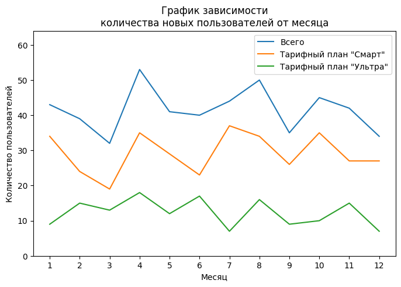

```python
df = user_behavior.groupby('user_id').head(1)

plt.figure(figsize=(8, 5))
plt.title('График зависимости\nколичества новых пользователей от месяца')
df.groupby('month')['month'].count().plot()
df[df['tariff'] == 'smart'].groupby('month')['month'].count().plot()
df[df['tariff'] == 'ultra'].groupby('month')['month'].count().plot()
plt.ylabel('Количество пользователей')
plt.xlabel('Месяц')
plt.xticks([x for x in range(1, 13)])
plt.ylim(0, 64)
plt.legend(['Всего', 'Тарифный план "Смарт"', 'Тарифный план "Ультра"'])
plt.show()
```

```python
df.pivot_table(index='tariff', columns='month', values='user_id',
               aggfunc='count', margins=True).rename(
    index={'smart': 'Тарифный план "Смарт"',
           'ultra': 'Тарифный план "Ультра"', 'All': 'Всего'},
    columns={'All': 'Всего'}
).rename_axis(index='Кол-во новых пользователей', columns='Месяц')
```

| Месяц Кол-во новых пользователей | 1 | 2 | 3 | 4 | 5 | 6 | 7 | 8 | 9 | 10 | 11 | 12 | Всего |
| --- | --- | --- | --- | --- | --- | --- | --- | --- | --- | --- | --- | --- | --- |
| Тарифный план "Смарт" | 34 | 24 | 19 | 35 | 29 | 23 | 37 | 34 | 26 | 35 | 27 | 27 | 350 |
| Тарифный план "Ультра" | 9 | 15 | 13 | 18 | 12 | 17 | 7 | 16 | 9 | 10 | 15 | 7 | 148 |
| Всего | 43 | 39 | 32 | 53 | 41 | 40 | 44 | 50 | 35 | 45 | 42 | 34 | 498 |

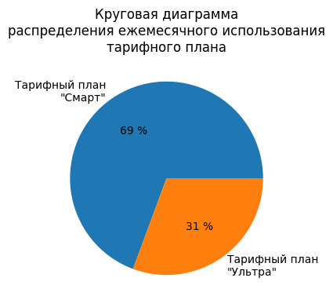

```python
binary_pie(user_behavior['tariff'] == 'smart',
           'Тарифный план\n"Смарт"', 'Тарифный план\n"Ультра"',
           'ежемесячного использования\nтарифного плана')
```

#### Услуги, включённые в абонентскую плату

##### Количество звонков, совершённых пользователем в течение месяца

```python
stat('calls', 'Количество звонков')
```

| Количество звонков | Всего | Тарифный план "Смарт" | Тарифный план "Ультра" |
| --- | --- | --- | --- |
| кол-во значений | 3214 | 2229 | 985 |
| кол-во уникальных | 184 | 133 | 182 |
| мин. | 0 | 0 | 0 |
| -1.5IQR | -1.0 | 6.0 | -20.5 |
| 25 % | 40.0 | 40.0 | 41.0 |
| мода | [69] | [69] | [0] |
| медиана | 62.0 | 60.0 | 74.0 |
| среднее ариф. | 63.04 | 58.46 | 73.39 |
| 75 % | 82.0 | 76.0 | 104.0 |
| +1.5IQR | 125.0 | 114.0 | 168.5 |
| макс. | 244 | 198 | 244 |
| размах | 244 | 198 | 244 |
| межквартильный размах | 42.0 | 36.0 | 63.0 |

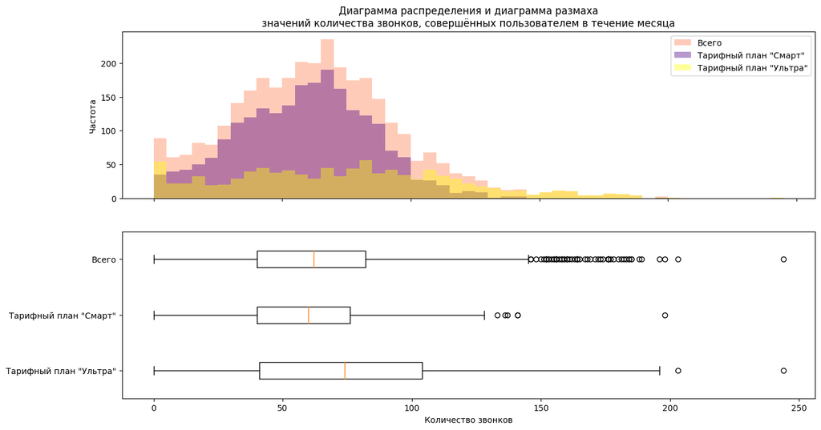

```python
triple_graph('calls', 'количества звонков, совершённых пользователем в течение месяца',
             'Количество звонков', 250, 5)
```

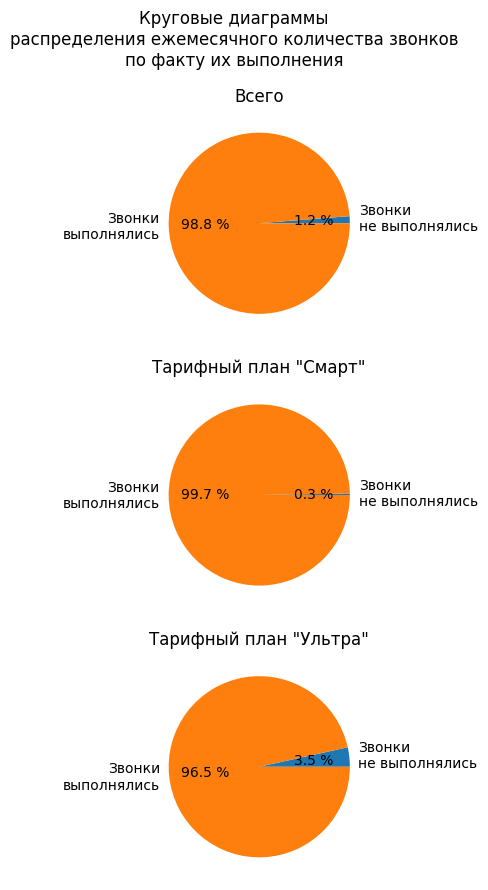

```python
binary_pie('calls', 'Звонки\nвыполнялись', 'Звонки\nне выполнялись',
           'ежемесячного количества звонков\nпо факту их выполнения', num=3)
```

- Значения определены для всех записей.
- Для 3214 записей встречается 184 различных уникальных значений. Причём для 2229 записей, относящихся к тарифному плану "Смарт", встречается 133 различных уникальных значений, а для 985 записей, относящихся к тарифному плану "Ультра", встречается 182 различных уникальных значения.
- Минимальное значение — 0, максимальное значение — 244 звонка в месяц. Значение 0 означает, что исходящие звонки с номеров абонентов не выполнялись в течение всего месяца. Значение 0 наблюдается для абонентов обоих тарифных планов. Однако, если для абонентов тарифного плана "Смарт" имеется незначительное количество записей со значением 0 (0,3 %), то для абонентов тарифного плана "Ультра" таких значений уже 3,5 %. Максимальное количество звонков в месяц, которое совершили абоненты тарифного плана "Смарт", равно 198, а тарифного плана "Ультра" — 244.
- Мода — 69 звонков в месяц. Причём такая же мода для распределения количества звонков в месяц у абонентов тарифного плана "Смарт". В распределении количества звонков абонентов тарифного плана "Ультра" модой является значение 0 по причине того, что значительная доля (3,5 %) приходится на это значение.
- Медиана — 62 звонка в месяц. У абонентов тарифного плана "Смарт" медиана принимает схожее значение — 60 звонков в месяц. У абонентов тарифного плана "Ультра" это значение несколько выше, медиана составляет 74 звонка в месяц.
- Распределение количества звонков носит унимодальный характер, смещено влево, с небольшим "хвостом" справа. Распределение количества звонков абонентов тарифного плана "Смарт" также имеет унимодальный характер, смещено влево, имеет небольшое плечо слева, с небольшим "хвостом" справа. Распределение количества звонков абонентов тарифного плана "Ультра" не обладает выраженным максимумом.
- Половина всех значений лежит вокруг медианы в диапазоне 40–82 звонка в месяц. Причём для абонентов тарифного плана "Смарт" половина всех значений лежит в диапазоне немного уже — 40–76 звонков, а для абонентов тарифного плана "Ультра" половина всех значений лежит в более широком диапазоне вокруг медианы — 41–104 звонков.
- Практически все значения не превышают 125 звонков в месяц. Для абонентов тарифного плана "Смарт" большинство значений не превышают 114 звонков в месяц, а для абонентов тарифного плана "Ультра" — 168 звонков в месяц.

##### Длительность звонков, совершённых пользователем в течение месяца

```python
stat('minutes', 'Длительность звонков, мин')
```

| Длительность звонков, мин | Всего | Тарифный план "Смарт" | Тарифный план "Ультра" |
| --- | --- | --- | --- |
| кол-во значений | 3214 | 2229 | 985 |
| кол-во уникальных | 925 | 732 | 641 |
| мин. | 0.0 | 0.0 | 0.0 |
| -1.5IQR | -17.5 | 27.5 | -184.0 |
| 25 % | 282.0 | 282.0 | 284.0 |
| мода | [0.0] | [437.0] | [0.0] |
| медиана | 443.0 | 422.0 | 518.0 |
| среднее ариф. | 451.24 | 417.93 | 526.62 |
| 75 % | 589.0 | 545.0 | 752.0 |
| +1.5IQR | 903.5 | 816.5 | 1220.0 |
| макс. | 1673.0 | 1435.0 | 1673.0 |
| размах | 1673.0 | 1435.0 | 1673.0 |
| межквартильный размах | 307.0 | 263.0 | 468.0 |

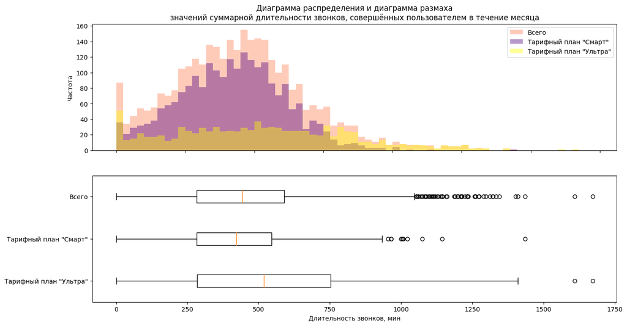

```python
triple_graph('minutes',
      'суммарной длительности звонков, совершённых пользователем в течение месяца',
      'Длительность звонков, мин', 1750, 25)
```

- Значения определены для всех записей.
- Для 3214 записей встречается 925 различных уникальных значений. Причём для 2229 записей, относящихся к тарифному плану "Смарт", встречается 732 различных уникальных значения, а для 985 записей, относящихся к тарифному плану "Ультра", встречается 641 различное уникальное значение.
- Минимальное значение — 0, которое означает неотвеченный вызов. Такое минимальное значение есть как среди звонков абонентов тарифного плана "Смарт", так и среди звонков абонентов тарифного плана "Ультра". Максимальное значение — 1673 мин, которое определяется максимальным значением длительности звонков, совершённых в течение одного месяца абонентами тарифного плана "Ультра". Максимальная длительность звонков, совершённых в течение месяца абонентами тарифного плана "Смарт", составляет 1435 мин.
- Модой является значение 0, что говорит о большом количестве неотвеченных звонков. Такая же ситуация наблюдается среди звонков абонентов тарифного плана "Ультра". А вот модой длительности звонков у абонентов тарифного плана "Смарт" является значение 437 мин.
- Медиана — 443 мин, среднее арифметическое — 451 мин. В распределении суммарной ежемесячной длительности звонков абонентов тарифного плана "Смарт" медианой является 422 мин, средним арифметическим — 418 мин в месяц. У абонентов тарифного плана "Ультра" медианой является 518 мин, средним арифметическим — 527 мин в месяц.
- Близость значений медианы и среднего арифметического может свидетельствовать о близости формы распределения к нормальному. Действительно, распределение значений суммарной ежемесячной длительности звонков имеет унимодальный характер, немного смещено влево, с небольшим "хвостом" справа. Схожее распределение значений наблюдается у значений длительности звонков абонентов тарифного плана "Смарт". Распределение значений длительности звонков абонентов тарифного плана "Ультра" не имеет выраженного максимума.
- Половина всех значений лежит в диапазоне 282–589 мин в месяц. Немного уже этот диапазон для значений длительности звонков абонентов тарифного плана "Смарт" — 282–545 мин в месяц. Для значений длительности звонков абонентов тарифного плана "Ультра", наоборот, половина всех значений лежит в более широком диапазоне 284–752 мин в месяц.
- Практически все значения не превышают 903 мин в месяц. У абонентов тарифного плана "Смарт" суммарная длительность звонков в большинстве случаев не превышает 816 мин в месяц, а у абонентов тарифного плана "Ультра" — 1220 мин в месяц.

##### Количество смс-сообщений, отправленных пользователем в течение месяца

```python
stat('messages', 'Количество смс-сообщений')
```

| Количество смс-сообщений | Всего | Тарифный план "Смарт" | Тарифный план "Ультра" |
| --- | --- | --- | --- |
| кол-во значений | 3214 | 2229 | 985 |
| кол-во уникальных | 180 | 124 | 178 |
| мин. | 0 | 0 | 0 |
| -1.5IQR | -42.0 | -33.5 | -71.5 |
| 25 % | 9.0 | 10.0 | 6.0 |
| мода | [0] | [0] | [0] |
| медиана | 30.0 | 28.0 | 38.0 |
| среднее ариф. | 38.28 | 33.38 | 49.36 |
| 75 % | 57.0 | 51.0 | 79.0 |
| +1.5IQR | 102.0 | 89.5 | 147.5 |
| макс. | 224 | 143 | 224 |
| размах | 224 | 143 | 224 |
| межквартильный размах | 48.0 | 41.0 | 73.0 |

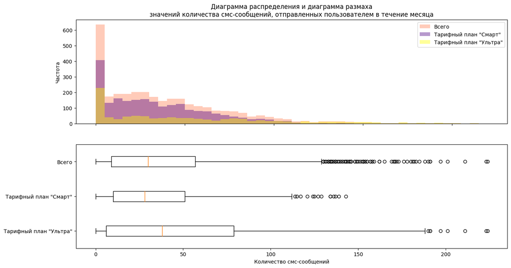

```python
triple_graph('messages',
      'количества смс-сообщений, отправленных пользователем в течение месяца',
      'Количество смс-сообщений', 225, 5)
```

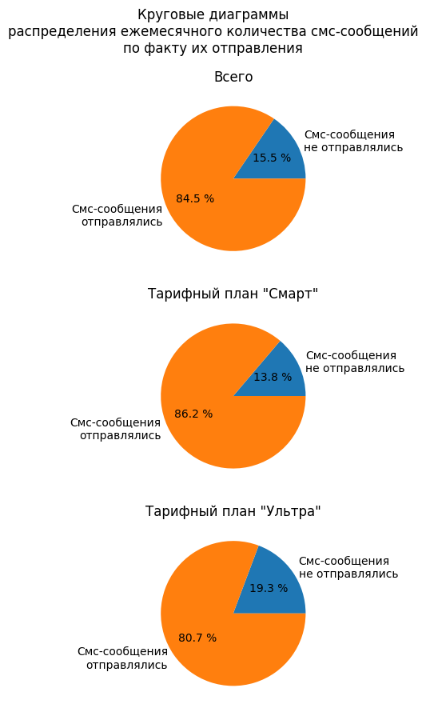

```python
binary_pie('messages',
           'Смс-сообщения\nотправлялись', 'Смс-сообщения\nне отправлялись',
           'ежемесячного количества смс-сообщений\nпо факту их отправления', num=3)
```

```python
stat('messages', 'Количество смс-сообщений',
     df=user_behavior.loc[user_behavior['messages'] > 0])
```

| Количество смс-сообщений | Всего | Тарифный план "Смарт" | Тарифный план "Ультра" |
| --- | --- | --- | --- |
| кол-во значений | 2717 | 1922 | 795 |
| кол-во уникальных | 179 | 123 | 177 |
| мин. | 1 | 1 | 1 |
| -1.5IQR | -28.0 | -23.0 | -44.25 |
| 25 % | 19.0 | 17.0 | 24.0 |
| мода | [20] | [20] | [6, 20, 40] |
| медиана | 38.0 | 34.0 | 51.0 |
| среднее ариф. | 45.28 | 38.72 | 61.16 |
| 75 % | 63.0 | 55.0 | 87.5 |
| +1.5IQR | 104.0 | 91.0 | 146.25 |
| макс. | 224 | 143 | 224 |
| размах | 223 | 142 | 223 |
| межквартильный размах | 44.0 | 38.0 | 63.5 |

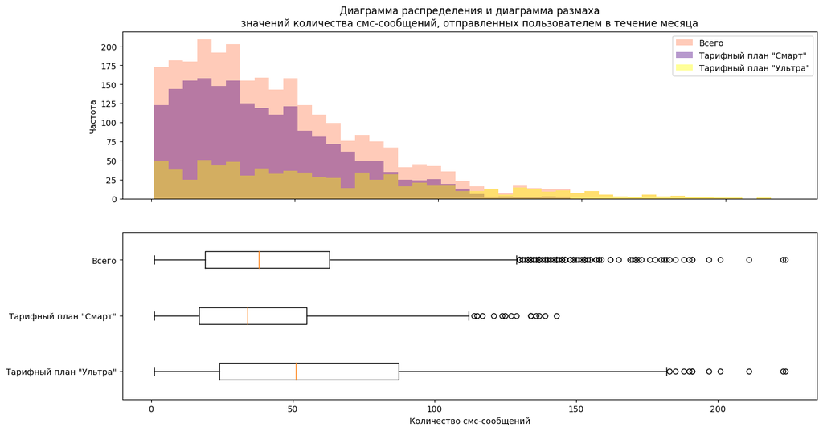

```python
triple_graph('messages',
             'количества смс-сообщений, отправленных пользователем в течение месяца',
             'Количество смс-сообщений', 225, 5, x_min=1,
             df=user_behavior.loc[user_behavior['messages'] > 0])
```

- Значения определены для всех записей.
- Для 3214 записей встречается 180 различных уникальных значений. Причём для 2229 записей, относящихся к тарифному плану "Смарт", встречается 124 различных уникальных значений, а для 985 записей, относящихся к тарифному плану "Ультра", встречается 178 различных уникальных значений.
- Среди значений количества отправленных смс-сообщений есть значение 0, которое является модой и для всех наблюдений (15,5 % всех наблюдений), и среди наблюдений, относящихся как к тарифному плану "Смарт" (13,8 % наблюдений среди абонентов тарифного плана "Смарт"), так и к тарифному плану "Ультра" (19,3 % наблюдений среди абонентов тарифного плана "Ультра").
- Медианное значение количества отправленных смс-сообщений составляет 30 сообщений. Причём абонентами тарифного плана "Смарт" в среднем отправлялось немного меньше сообщений: медианное значение составляет 28 смс-сообщений; а абонентами тарифного плана "Ультра" — больше: медианное значение составляет 38 смс-сообщений.
- Максимальное количество смс-сообщений, отправленных за один месяц абонентами тарифного плана "Смарт", составляет 143 сообщения, а тарифного плана "Ультра" — 224 сообщений.
- Поскольку количество нулей среди значений количества отправленных смс-сообщений является значительным, можно рассматривать распределение значений как состоящее отдельно из значений натурального ряда и отдельно из значения 0. Поэтому далее необходимо рассмотреть распределение значений количества действительно отправленных сообщений.
- Для 2717 записей с ненулевыми значениями встречается 179 различных уникальных значений. Причём для 1922 записей с ненулевыми значениями, относящихся к тарифному плану "Смарт", встречается 123 различных уникальных значений, а для 795 записей с ненулевыми значениями, относящихся к тарифному плану "Ультра", встречается 177 различных уникальных значений.
- Минимальное значение — 1 сообщение в месяц. Это же значение является минимальным и среди значений количества смс-сообщений, отправленных абонентами тарифных планов "Смарт" и "Ультра". Максимальное значение — 224 смс-сообщения в месяц, характеризует также максимальное количество сообщений в месяц, отправленных абонентами тарифного плана "Ультра". Максимальное количество смс-сообщений, отправленных в течение месяца абонентами тарифного плана "Смарт", составляет 143.
- Мода — 20 смс-сообщений в месяц. Характеризует как весь набор наблюдений, так и распределения количеств сообщений, отправленных абонентами тарифных планов "Смарт" и "Ультра".
- Медиана — 38 смс-сообщений в месяц. Причём медианное значение количества смс, отправленных абонентами тарифного плана "Смарт", несколько ниже — 34, а отправленных абонентами тарифного плана "Ультра" выше — 51.
- Распределение значений количества смс-сообщений, действительно отправленных абонентами, носит унимодальный характер, смещено влево, с длинным "хвостом" справа. Распределение значений количества сообщений, действительно отправленных абонентами тарифного плана "Смарт", носит схожий характер. А распределение значений количества сообщений, действительно отправленных абонентами тарифного плана "Ультра", не имеет выраженного максимума.
- Половина всех значений, когда сообщения действительно отправлялись абонентами, лежит в диапазоне 19–63. Абонентами тарифного плана "Смарт" отправлялось 17–55 смс-сообщений, а тарифного плана "Ультра" — 24–87 смс-сообщений.
- Практически всегда количество отправляемых смс-сообщений в месяц не превышает 104. Абоненты тарифного плана "Смарт" отправляют почти всегда не более 91, а тарифного плана "Ультра" — не более 146 смс-сообщений.

##### Количество интернет-сессий, проведённых пользователем в течение месяца

```python
stat('sessions', 'Количество интернет-сессий')
```

| Количество интернет-сессий | Всего | Тарифный план "Смарт" | Тарифный план "Ультра" |
| --- | --- | --- | --- |
| кол-во значений | 3214 | 2229 | 985 |
| кол-во уникальных | 105 | 102 | 90 |
| мин. | 0 | 0 | 0 |
| -1.5IQR | 12.0 | 19.5 | -4.0 |
| 25 % | 35.0 | 40.0 | 24.0 |
| мода | [45, 56] | [53] | [37, 50] |
| медиана | 48.0 | 51.0 | 38.0 |
| среднее ариф. | 46.48 | 50.04 | 38.43 |
| 75 % | 59.0 | 61.0 | 52.0 |
| +1.5IQR | 84.0 | 82.5 | 80.0 |
| макс. | 118 | 118 | 97 |
| размах | 118 | 118 | 97 |
| межквартильный размах | 24.0 | 21.0 | 28.0 |

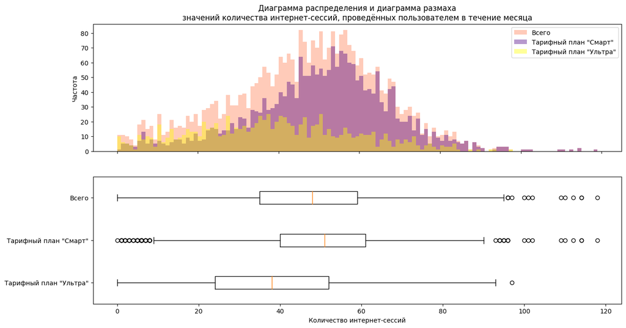

```python
triple_graph('sessions',
             'количества интернет-сессий, проведённых пользователем в течение месяца',
             'Количество интернет-сессий', 120, 1)
```

- Значения определены для всех записей.
- Для 3214 записей встречается 105 различных уникальных значений. Причём для 2229 записей, относящихся к тарифному плану "Смарт", встречается 102 различных уникальных значения, а для 985 записей, относящихся к тарифному плану "Ультра", встречается 90 различных уникальных значений.
- Минимальное значение 0 является характеристикой как всего набора данных, так и минимальным значением количества интернет-сессий абонентов тарифных планов "Смарт" и "Ультра". Значение ноль указывает на неиспользование интернета в течение месяца. Встречается в наборе данных нечасто, поэтому нет необходимости его рассматривать отдельно от остальных, натуральных значений. Максимальное значение — 118 интернет-сессий в месяц, является также максимальным числом интернет-сессий, проведённых в течение месяца абонентами тарифного плана "Смарт". Максимальное число интернет-сессий, проведённых абонентами тарифного плана "Ультра" в течение одного месяца, составляет 97.
- Моды — 45 и 56 интернет-сессий в месяц. У абонентов тарифного плана "Смарт" мода количества интернет-сессий — 53. У абонентов тарифного плана "Ультра" модами являются 37 и 50 интернет-сессий в месяц.
- Медиана — 48 интернет-сессий в месяц. Причём в распределении количества интернет-сессий, проведённых абонентами тарифного плана "Смарт", медианное значение 51 расположено близко. А медианное значение количества интернет-сессий, проведённых абонентами тарифного плана "Ультра", значительно меньше и составляет 38.
- Распределение значений количества интернет-сессий в месяц носит унимодальный характер, смещено влево, с пологим подъёмом слева и довольно крутым спуском справа, с небольшим "хвостом" справа. Характер распределения количества проведённых абонентами тарифного плана "Смарт" интернет-сессий является схожим. А вот распределение количества проведённых абонентами тарифного плана "Ультра" интернет-сессий широкое, с нечётко выраженным максимумом.
- Половина всех значений лежит в диапазоне 35–59 интернет-сессий в месяц. Половина всех наблюдений, относящихся к абонентам тарифного плана "Смарт", характеризуется схожим диапазоном — 40–61 интернет-сессий в месяц, а относящихся к абонентам тарифного плана "Ультра" — смещённым в область меньших значений диапазоном 24–52 интернет-сессии в месяц.
- Практически все значения не превышают 84 интернет-сессий в месяц. Причём у абонентов тарифных планов "Смарт" и "Ультра" количество интернет-сессий не превышает 82 и 80 в месяц, соответственно.

##### Объём интернет-трафика, израсходованный пользователем в течение месяца

```python
stat('mb_used', 'Объём интернет-трафика, Мбайт')
```

| Объём интернет-трафика, Мбайт | Всего | Тарифный план "Смарт" | Тарифный план "Ультра" |
| --- | --- | --- | --- |
| кол-во значений | 3214 | 2229 | 985 |
| кол-во уникальных | 3202 | 2228 | 975 |
| мин. | 0.0 | 0.0 | 0.0 |
| -1.5IQR | 3544.0725 | 5406.96 | -3293.135 |
| 25 % | 12491.89 | 12643.01 | 11770.26 |
| мода | [0.0] | [0.0] | [0.0] |
| медиана | 16943.18 | 16506.84 | 19308.01 |
| среднее ариф. | 17207.61 | 16208.39 | 19468.81 |
| 75 % | 21424.62 | 20042.93 | 26837.69 |
| +1.5IQR | 30342.2775 | 27606.72 | 41909.155 |
| макс. | 49745.69 | 38552.45 | 49745.69 |
| размах | 49745.69 | 38552.45 | 49745.69 |
| межквартильный размах | 8932.735 | 7399.92 | 15067.43 |

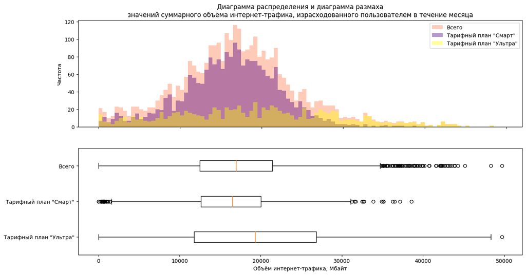

```python
triple_graph('mb_used',
             'суммарного объёма интернет-трафика, израсходованного пользователем в течение месяца',
             'Объём интернет-трафика, Мбайт', 50000, 500)
```

- Значения определены для всех записей.
- Для 3214 записей встречается 3202 различных уникальных значения. Причём для 2229 записей, относящихся к тарифному плану "Смарт", встречается 2228 различных уникальных значений, а для 985 записей, относящихся к тарифному плану "Ультра", встречается 975 различных уникальных значений.
- Минимальное значение — 0, свидетельствующее о том, что данные не передавались в сеть. Среди всех записей на это значение приходится лишь незначительная часть записей, поэтому не требуется рассматривать их отдельно от остальных, положительных значений объёма интернет-трафика. Максимальное значение — 49 746 Мбайт, оно же является максимальным среди значений ежемесячного объёма интернет-трафика, использованного абонентами тарифного плана "Ультра". Максимальное значение ежемесячного объёма интернет-трафика, израсходованного абонентами тарифного плана "Смарт", составляет 38 553 Мбайт.
- Поскольку шкала измерения признака является абсолютная шкалой и практически все значения признака являются уникальными, модой является значение 0.
- Медиана — 16 943 Мбайт (для всего набора наблюдений), и среднее арифметическое — 17 208 Мбайт, расположены близко. Среди значений объёма интернет-трафика, израсходованного в течение месяца абонентами тарифного плана "Смарт", медианой является значение 16 507 Мбайт, а средним арифметическим — 16 208 Мбайт (тоже расположены близко, но смещены в область меньших значений). Медианное значение объёма израсходованного абонентами тарифного плана "Ультра" интернет-трафика составляет немного больше — 19 308 Мбайт, а среднее арифметическое также расположено близко — 19 469 Мбайт.
- Распределение значений унимодальное, практически симметричное, с небольшим "хвостом" справа. Значения объёма интернет-трафика, израсходованного абонентами тарифного плана "Смарт", имеют схожее распределение, хоть медианное значение и смещено в область меньших значений. Имеет менее длинный "хвост" справа. Распределение значений объёма интернет-трафика, израсходованного абонентами тарифного плана "Ультра", уширенное, без чётко выраженного максимума.
- Половина всех значений лежит в диапазоне 12 492–21 425 Мбайт. Немного уже межквартильный размах значений объёма интернет-трафика, израсходованного абонентами тарифного плана "Смарт", — 12 643–20 043 Мбайт. А вот межквартильный размах значений объёма интернет-трафика, израсходованный абонентами тарифного плана "Ультра", значительно шире и составляет от 11 770 до 26 838 Мбайт.
- Практически все значения не превышают 30 342 Мбайт. Причём абоненты тарифного плана "Смарт" расходуют почти всегда не более 27 607 Мбайт, а тарифного плана "Ультра" — не более 41 909 Мбайт.

#### Дополнительные услуги, не включённые в абонентскую плату

##### Суммарная длительность звонков, не включённых в абонентскую плату

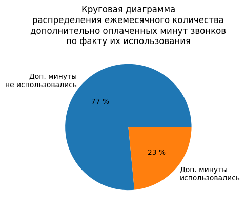

```python
binary_pie(user_behavior['paid_minutes'] > 0,
           'Доп. минуты\nиспользовались', 'Доп. минуты\nне использовались',
           'ежемесячного количества\nдополнительно оплаченных минут звонков\nпо факту их использования')
```

```python
print('Количество абонентов тарифного плана "Ультра",',
      '\nиспользовавших дополнительные минуты разговора:',
      len(user_behavior[(user_behavior['tariff'] == 'ultra') &
                        (user_behavior['paid_minutes'] > 0)]))
```

```
Количество абонентов тарифного плана "Ультра",
использовавших дополнительные минуты разговора: 0
```

```python
descriptive_statistics(
    user_behavior.loc[user_behavior['paid_minutes'] > 0, 'paid_minutes'], 'Всего'
    ).join(descriptive_statistics(
                    user_behavior.loc[(user_behavior['tariff'] == 'smart') &
                                      (user_behavior['paid_minutes'] > 0),
                                      'paid_minutes'], 'Тарифный план "Смарт"')
    ).rename_axis('Количество доп. звонков', axis=1)
```

| Количество доп. звонков | Всего | Тарифный план "Смарт" |
| --- | --- | --- |
| кол-во значений | 754 | 754 |
| кол-во уникальных | 290 | 290 |
| мин. | 1.0 | 1.0 |
| -1.5IQR | -92.0 | -92.0 |
| 25 % | 44.0 | 44.0 |
| мода | [32.0] | [32.0] |
| медиана | 100.0 | 100.0 |
| среднее ариф. | 123.0 | 123.0 |
| 75 % | 172.0 | 172.0 |
| +1.5IQR | 292.0 | 292.0 |
| макс. | 935.0 | 935.0 |
| размах | 934.0 | 934.0 |
| межквартильный размах | 128.0 | 128.0 |

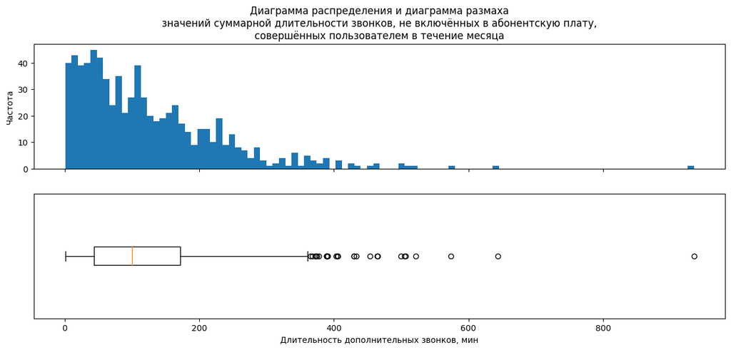

```python
graph(user_behavior.loc[user_behavior['paid_minutes'] > 0, 'paid_minutes'],
      'суммарной длительности звонков, не включённых в абонентскую плату,' +
      '\nсовершённых пользователем в течение месяца',
      'Длительность дополнительных звонков, мин')
```

- Среди наблюдений "уникальный идентификатор пользователя—месяц пользования тарифным планом" в 23 % случаев (754 наблюдений) были использованы дополнительные минуты разговора сверх того количества, которое включено в абонентскую плату.
- Абоненты тарифного плана "Ультра" не использовали дополнительные минуты разговора. Суммарная длительность их разговоров не превышала значения длительности разговоров, предоставляемого тарифным планом в качестве основной услуги.
- Дополнительные минуты разговора использовали абоненты тарифного плана "Смарт". Таким образом, распределение значений суммарной длительности звонков, не включённых в абонентскую плату, характеризует поведение пользователей только тарифного плана "Смарт".
  - Для 754 записей встречается 290 различных значений.
  - Минимальное значение — 1 мин, максимальное — 935 мин (15,6 ч).
  - Мода — 32 мин, медиана — 100 мин, среднее арифметическое — 123 мин.
  - Среднее арифметическое и медиана расположены близко, но на значительном удалении от моды. Это обусловлено характером распределения. Распределение значений имеет экспоненциальный характер: значения смещены влево, наблюдается длинный "хвост" справа.
  - Половина всех значений лежит в диапазоне 44–172 мин.
  - Большинство значений не превосходит 292 мин (4,9 ч).

##### Стоимость дополнительных минут разговора

```python
descriptive_statistics(
    user_behavior.loc[user_behavior['cost_minutes'] > 0, 'cost_minutes'], 'Всего'
    ).join(descriptive_statistics(
        user_behavior.loc[(user_behavior['tariff'] == 'smart') &
                          (user_behavior['cost_minutes'] > 0),
                          'cost_minutes'], 'Тарифный план "Смарт"')
    ).rename_axis('Стоимость доп. минут разговора, руб.', axis=1)
```

| Стоимость доп. минут разговора, руб. | Всего | Тарифный план "Смарт" |
| --- | --- | --- |
| кол-во значений | 754 | 754 |
| кол-во уникальных | 290 | 290 |
| мин. | 3.0 | 3.0 |
| -1.5IQR | -276.0 | -276.0 |
| 25 % | 132.0 | 132.0 |
| мода | [96.0] | [96.0] |
| медиана | 300.0 | 300.0 |
| среднее ариф. | 368.99 | 368.99 |
| 75 % | 516.0 | 516.0 |
| +1.5IQR | 876.0 | 876.0 |
| макс. | 2805.0 | 2805.0 |
| размах | 2802.0 | 2802.0 |
| межквартильный размах | 384.0 | 384.0 |

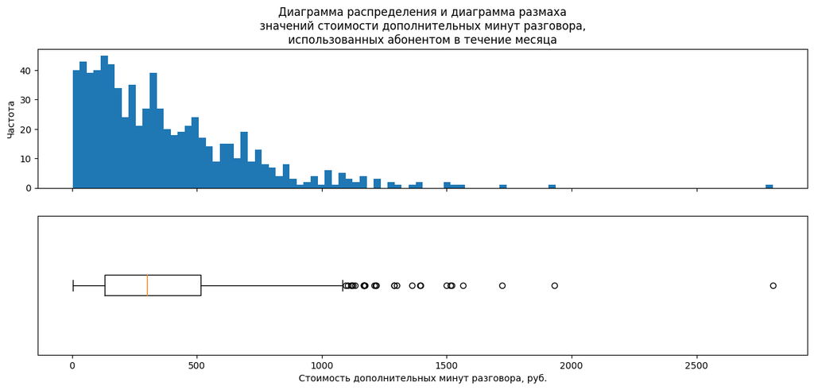

```python
graph(user_behavior.loc[user_behavior['cost_minutes'] > 0, 'cost_minutes'],
      'стоимости дополнительных минут разговора,' +
      '\nиспользованных абонентом в течение месяца',
      'Стоимость дополнительных минут разговора, руб.')
```

- Дополнительные минуты разговора использовали только абоненты тарифного плана "Смарт". Поскольку стоимость дополнительных минут разговора рассчитывалась путём умножения длительности звонков, не включённых в абонентскую плату, на цену одной минуты разговора, то форма распределения значений стоимости дополнительных минут разговора повторяет форму распределения значений суммарной длительности звонков, не включённых в абонентскую плату.
  - Распределение значений также имеет экспоненциальный характер: значения смещены влево, наблюдается длинный "хвост" справа.
  - Минимальное значение — 3 руб., максимальное — 2805 руб.
  - Мода — 96 руб., медиана — 300 руб., среднее арифметическое — 369 руб.
  - Половина значений лежит в диапазоне 132–516 руб.
  - Большинство значений не превышает 876 руб.

##### Суммарное количество смс-сообщений, не включённых в абонентскую плату

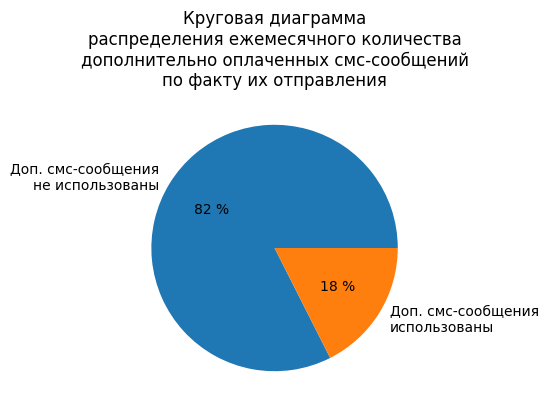

```python
binary_pie(user_behavior['paid_messages'] > 0,
           'Доп. смс-сообщения\nиспользованы', 'Доп. смс-сообщения\nне использованы',
           'ежемесячного количества\nдополнительно оплаченных смс-сообщений' +
           '\nпо факту их отправления')
```

```python
print('Количество абонентов тарифного плана "Ультра",',
       '\nиспользовавших дополнительные смс-сообщения:',
      len(user_behavior[(user_behavior['tariff'] == 'ultra') &
                        (user_behavior['paid_messages'] > 0)]))
```

```
Количество абонентов тарифного плана "Ультра",
использовавших дополнительные смс-сообщения: 0
```

```python
descriptive_statistics(
    user_behavior.loc[user_behavior['paid_messages'] > 0, 'paid_messages'], 'Всего'
    ).join(descriptive_statistics(
        user_behavior.loc[(user_behavior['tariff'] == 'smart') &
                          (user_behavior['paid_messages'] > 0),
                          'paid_messages'], 'Тарифный план "Смарт"')
    ).rename_axis('Количество доп. смс-сообщений', axis=1)
```

| Количество доп. смс-сообщений | Всего | Тарифный план "Смарт" |
| --- | --- | --- |
| кол-во значений | 564 | 564 |
| кол-во уникальных | 73 | 73 |
| мин. | 1 | 1 |
| -1.5IQR | -17.5 | -17.5 |
| 25 % | 9.0 | 9.0 |
| мода | [1] | [1] |
| медиана | 18.5 | 18.5 |
| среднее ариф. | 22.92 | 22.92 |
| 75 % | 33.0 | 33.0 |
| +1.5IQR | 54.5 | 54.5 |
| макс. | 93 | 93 |
| размах | 92 | 92 |
| межквартильный размах | 24.0 | 24.0 |

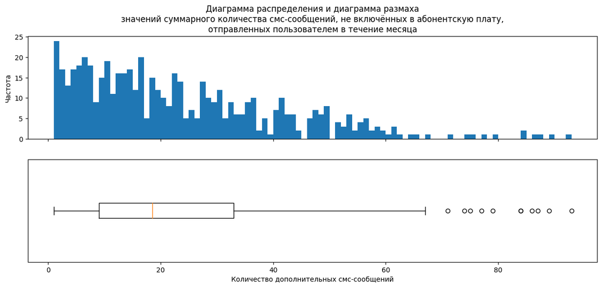

```python
graph(user_behavior.loc[user_behavior['paid_messages'] > 0, 'paid_messages'],
      'суммарного количества смс-сообщений, не включённых в абонентскую плату,' +
      '\nотправленных пользователем в течение месяца',
      'Количество дополнительных смс-сообщений', bins=[x for x in range(1, 94)])
```

- Среди наблюдений "уникальный идентификатор пользователя—месяц пользования тарифным планом" в 18 % случаев (564 наблюдений) были использованы дополнительные смс-сообщения сверх того количества, которое включено в абонентскую плату.
- Абоненты тарифного плана "Ультра" не использовали дополнительные смс-сообщения. Суммарное количество отправленных ими смс-сообщений не превышало значения количества смс-сообщений, предоставляемого тарифным планом в качестве основной услуги.
- Дополнительные смс-сообщения использовали абоненты тарифного плана "Смарт". Таким образом, распределение значений суммарного количества смс-сообщений, не включённых в абонентскую плату, характеризует поведение пользователей только тарифного плана "Смарт".
  - Для 564 записей встречается 73 различных значений.
  - Минимальное значение — 1 сообщение, максимальное — 93 сообщения.
  - Мода — 1 сообщение, медиана — 18,5.
  - Распределение значений треугольное: значения смещены влево, наблюдается небольшой "хвост" справа. Мода — крайняя точка слева, является максимумом распределения. Из-за малого количества уникальных значений распределение зашумлено, имеет характер более дискретного распределения, нежели непрерывного.
  - Половина всех значений лежит в диапазоне 9–33 сообщения.
  - Большинство значений не превосходит 54 сообщений.

##### Стоимость дополнительных смс-сообщений

```python
descriptive_statistics(
    user_behavior.loc[user_behavior['cost_messages'] > 0, 'cost_messages'], 'Всего'
    ).join(descriptive_statistics(
        user_behavior.loc[(user_behavior['tariff'] == 'smart') &
                          (user_behavior['cost_messages'] > 0),
                          'cost_messages'], 'Тарифный план "Смарт"')
    ).rename_axis('Стоимость доп. смс-сообщений, руб.', axis=1)
```

| Стоимость доп. смс-сообщений, руб. | Всего | Тарифный план "Смарт" |
| --- | --- | --- |
| кол-во значений | 564 | 564 |
| кол-во уникальных | 73 | 73 |
| мин. | 3.0 | 3.0 |
| -1.5IQR | -52.5 | -52.5 |
| 25 % | 27.0 | 27.0 |
| мода | [3.0] | [3.0] |
| медиана | 55.5 | 55.5 |
| среднее ариф. | 68.77 | 68.77 |
| 75 % | 99.0 | 99.0 |
| +1.5IQR | 163.5 | 163.5 |
| макс. | 279.0 | 279.0 |
| размах | 276.0 | 276.0 |
| межквартильный размах | 72.0 | 72.0 |

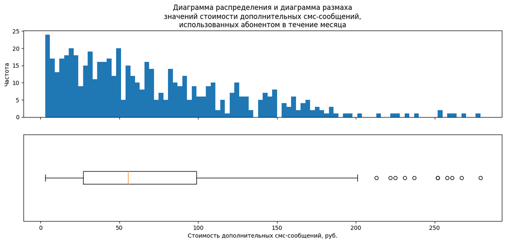

```python
graph(user_behavior.loc[user_behavior['cost_messages'] > 0, 'cost_messages'],
      'стоимости дополнительных смс-сообщений,' +
      '\nиспользованных абонентом в течение месяца',
      'Стоимость дополнительных смс-сообщений, руб.',
      bins=[x for x in range(3, 280, 3)])
```

- Дополнительные смс-сообщения использовали только абоненты тарифного плана "Смарт". Поскольку стоимость дополнительных смс-сообщений рассчитывалась путём умножения количества смс-сообщений, не включённых в абонентскую плату, на цену одного смс-сообщения, то форма распределения значений стоимости дополнительных смс-сообщений повторяет форму распределения значений суммарного количества смс-сообщений, не включённых в абонентскую плату.
  - Распределение значений также имеет треугольный характер: значения смещены влево, наблюдается небольшой "хвост" справа. Мода также является максимумом распределения и крайним левым значением.
  - Минимальное значение — 3 руб., максимальное — 279 руб.
  - Мода — 3 руб., медиана — 55,5 руб., среднее арифметическое — 69 руб.
  - Половина значений лежит в диапазоне 27–99 руб.
  - Большинство значений не превышает 163 руб.

##### Суммарный объём израсходованного интернет-трафика, не включённого в абонентскую плату

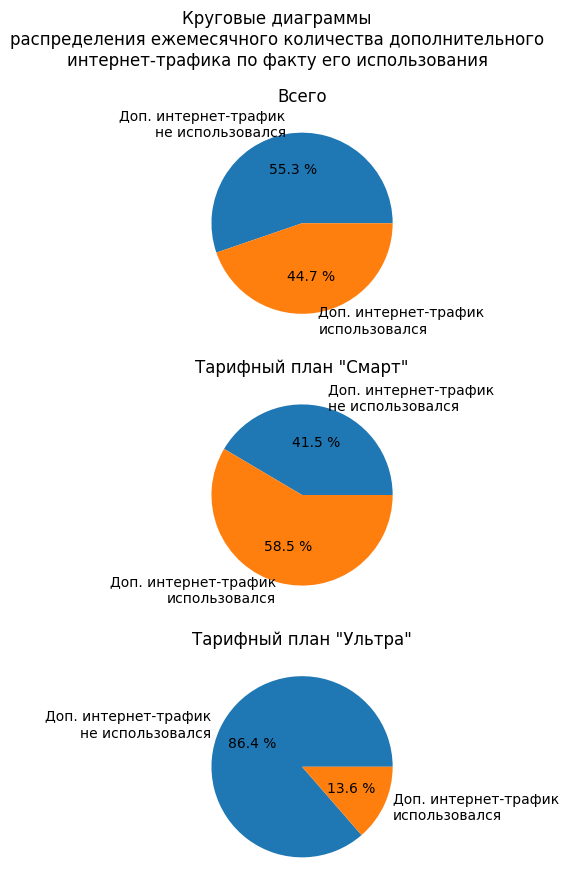

```python
binary_pie('paid_gb', 'Доп. интернет-трафик\nиспользовался',
           'Доп. интернет-трафик\nне использовался',
           'ежемесячного количества дополнительного' +
           '\nинтернет-трафика по факту его использования', num=3)
```

```python
stat('paid_gb', 'Объём доп. интернет-трафика, Гбайт',
     df=user_behavior.loc[user_behavior['paid_gb'] > 0])
```

| Объём доп. интернет-трафика, Гбайт | Всего | Тарифный план "Смарт" | Тарифный план "Ультра" |
| --- | --- | --- | --- |
| кол-во значений | 1438 | 1304 | 134 |
| кол-во уникальных | 23 | 22 | 17 |
| мин. | 1 | 1 | 1 |
| -1.5IQR | -3.5 | -3.5 | -3.625 |
| 25 % | 2.0 | 2.0 | 3.0 |
| мода | [2] | [2] | [2] |
| медиана | 4.0 | 4.0 | 5.0 |
| среднее ариф. | 5.18 | 5.11 | 5.89 |
| 75 % | 7.0 | 7.0 | 8.75 |
| +1.5IQR | 11.5 | 11.5 | 13.625 |
| макс. | 23 | 23 | 19 |
| размах | 22 | 22 | 18 |
| межквартильный размах | 5.0 | 5.0 | 5.75 |

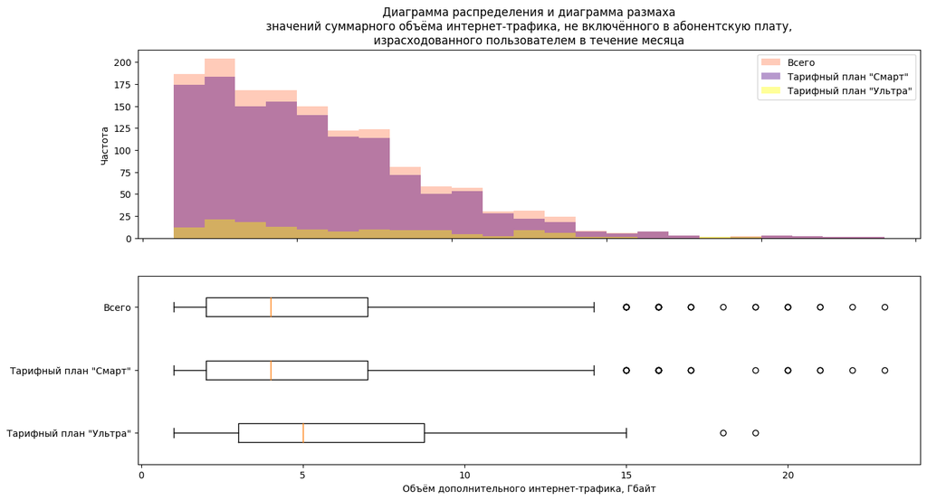

```python
triple_graph('paid_gb',
             'суммарного объёма интернет-трафика, не включённого в абонентскую плату,' +
             '\nизрасходованного пользователем в течение месяца',
             'Объём дополнительного интернет-трафика, Гбайт', 25, 1, x_min=1,
             df=user_behavior.loc[user_behavior['paid_gb'] > 0])
```

##### Стоимость дополнительного объёма интернет-трафика

```python
stat('cost_gb', 'Стоимость доп. объёма интернет-трафика, руб.',
     df=user_behavior.loc[user_behavior['cost_gb'] > 0])
```

| Стоимость доп. объёма интернет-трафика, руб. | Всего | Тарифный план "Смарт" | Тарифный план "Ультра" |
| --- | --- | --- | --- |
| кол-во значений | 1438 | 1304 | 134 |
| кол-во уникальных | 36 | 22 | 17 |
| мин. | 150 | 200 | 150 |
| -1.5IQR | -700.0 | -700.0 | -543.75 |
| 25 % | 400.0 | 400.0 | 450.0 |
| мода | [400] | [400] | [300] |
| медиана | 800.0 | 800.0 | 750.0 |
| среднее ариф. | 1008.87 | 1021.78 | 883.21 |
| 75 % | 1400.0 | 1400.0 | 1312.5 |
| +1.5IQR | 2300.0 | 2300.0 | 2043.75 |
| макс. | 4600 | 4600 | 2850 |
| размах | 4450 | 4400 | 2700 |
| межквартильный размах | 1000.0 | 1000.0 | 862.5 |

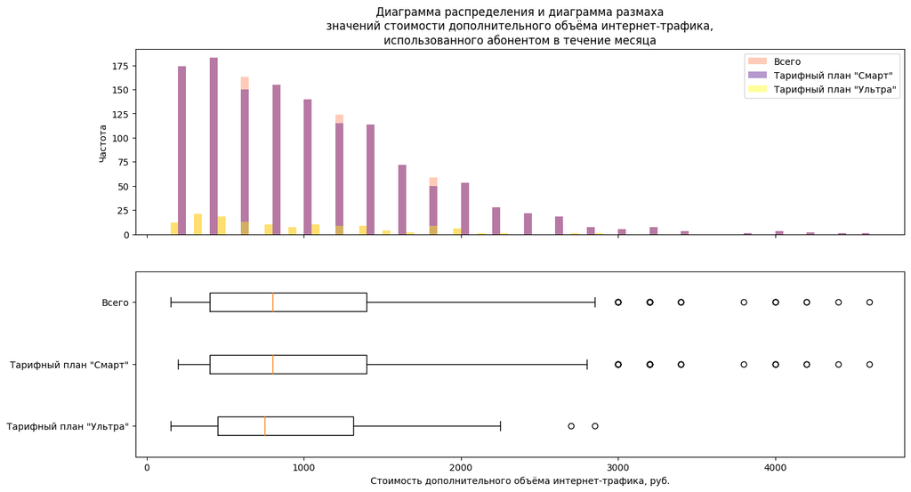

```python
triple_graph('cost_gb', 'стоимости дополнительного объёма интернет-трафика,' +
             '\nиспользованного абонентом в течение месяца',
             'Стоимость дополнительного объёма интернет-трафика, руб.',
             4601, 50, x_min=150, df=user_behavior.loc[user_behavior['cost_gb'] > 0])
```

#### Ежемесячная выручка

```python
stat('total_cost', 'Ежемесячная выручка, руб.')
```

| Ежемесячная выручка, руб. | Всего | Тарифный план "Смарт" | Тарифный план "Ультра" |
| --- | --- | --- | --- |
| кол-во значений | 3214 | 2229 | 985 |
| кол-во уникальных | 778 | 767 | 18 |
| мин. | 550.0 | 550.0 | 1950.0 |
| -1.5IQR | -146.5 | -777.0 | 1950.0 |
| 25 % | 750.0 | 550.0 | 1950.0 |
| мода | [1950.0] | [550.0] | [1950.0] |
| медиана | 1653.5 | 1023.0 | 1950.0 |
| среднее ариф. | 1529.08 | 1289.97 | 2070.15 |
| 75 % | 1950.0 | 1750.0 | 1950.0 |
| +1.5IQR | 3453.5 | 2823.0 | 1950.0 |
| макс. | 6770.0 | 6770.0 | 4800.0 |
| размах | 6220.0 | 6220.0 | 2850.0 |
| межквартильный размах | 1200.0 | 1200.0 | 0.0 |

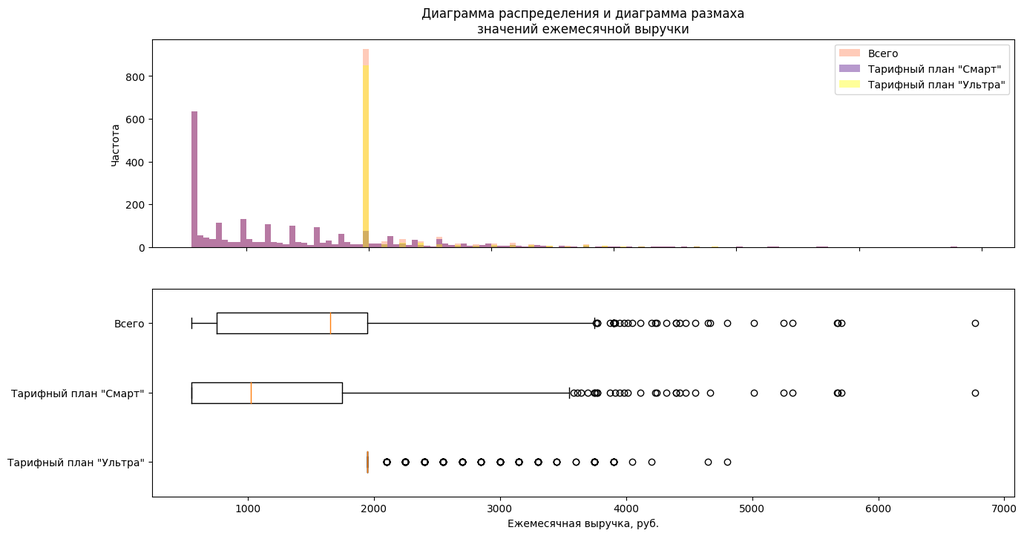

```python
triple_graph('total_cost', 'ежемесячной выручки', 'Ежемесячная выручка, руб.',
             7000, 50, x_min=550)
```

### Корреляционный анализ

```python
def two_graphs(values, title, ylabel, y_lim):
    '''
    Функция строит два графика с диаграммами размаха признака для каждого месяца:
    для наблюдений, относящихся к абонентам тарифного плана "Смарт"
    и к абонентам тарифного плана "Ультра".

    Принимает наименование признака, для которого строятся графики,
    подпись названия графика, подпись оси Oy,
    минимальное и максимальное значения на оси Oy.
    '''


    pivot = user_behavior.pivot_table(index='user_id',
                                      columns=['tariff', 'month'],
                                      values=values)
    pivot.reset_index(drop=True, inplace=True)

    fig, (ax1, ax2) = plt.subplots(1, 2, figsize=(15, 6))
    fig.suptitle(f'Диаграммы размаха значений\n{title}\nдля каждого месяца')
    fig.subplots_adjust(top=0.8)

    ax1.set_title('Тарифный план "Смарт"')
    pivot['smart'].plot.box(ax=ax1)
    ax1.set_ylim(y_lim)
    ax1.set_xlabel('Месяц')
    ax1.set_ylabel(ylabel)

    ax2.set_title('Тарифный план "Ультра"')
    pivot['ultra'].plot.box(ax=ax2)
    ax2.set_ylim(y_lim)
    ax2.set_xlabel('Месяц')
    ax2.set_ylabel(ylabel)

    plt.show()
```

```python
def two_hist(values, title, y_label, y_lim):
    '''
    Функция строит график с двумя диаграммами изменения
    средних значений признака по месяцам.

    Принимает наименование признака, для которого строится график,
    подпись названия графика, подпись оси Oy,
    минимальное и максимальное значения на оси Oy.
    '''

    user_behavior.pivot_table(
        index='month',
        columns='tariff',
        values=values,
        aggfunc='mean'
    ).plot.bar(rot=0,
               figsize=(6, 5))
    plt.title(f'Гистограмма средних значений\n{title}')
    plt.xlabel('Месяц')
    plt.ylabel(f'Среднее значение\n{y_label}')
    plt.ylim(y_lim)
    plt.legend(['Тарифный план "Смарт"', 'Тарифный план "Ультра"'])
    plt.show()
```

#### Ежемесячное изменение количества звонков

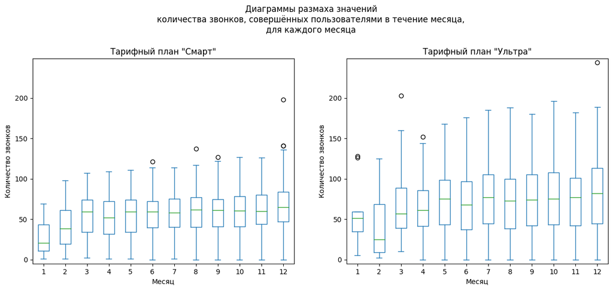

```python
two_graphs('calls',
           'количества звонков, совершённых пользователями в течение месяца,',
           'Количество звонков', (-5, 249))
```